# Cancer Predisposition Genome Report by CPSR

October 09, 2022

## Settings

### Sample metadata

- Sample name : **WGS_PCB-2020-005-BLD-2020-00354**

### Report configuration

The report is generated with *cpsr* version 1.0.0, ( *pcgr* version 1.0.2), using the following key settings:

- Genome assembly: **grch38**
- Report settings
  - R Markdown theme (Bootstrap): **default**
  - Datatable display: **light**
  - Non-floating TOC: **FALSE**
- Control population gnomAD: **Global non-cancer subset**
- Upper MAF threshold (gnomAD) for unclassified variants included in report: **0.01**
- Ignore non-proteincoding variants in report: **TRUE**
- Generate CPSR variant classifications also for existing ClinVar variants: **TRUE**
- Ignore ClinVar variants in target genes if they are reported only for non-cancer phenotypes: **FALSE**
- Include [secondary findings](https://www.ncbi.nlm.nih.gov/clinvar/docs/acmg/) in report: **TRUE**
- Include GWAS hits in report: **TRUE**
  - Minimum p-value for association: **0.000005**
- Variant Effect Predictor (VEP) settings:
  - Transcript set: **GENCODE - basic set (v39)**
  - Transcript pick order: **canonical,appris,biotype,ccds,rank,tsl,length,mane**
  - Regulatory regions annotation: **TRUE**

### Virtual gene panel

Cancer predisposition geneset subject to analysis/screening in this report:

- **[CPSR superpanel of cancer predisposition genes - v3.1](https://sigven.github.io/cpsr/articles/virtual_panels.html#panel-0)**
  - Diagnostic-grade genes (applicable to Genomics England panels only): **FALSE**
- Exploratory virtual gene panel (research)

[ABCB11](https://www.ncbi.nlm.nih.gov/gene/8647)

[ABL1](https://www.ncbi.nlm.nih.gov/gene/25)

[ABL2](https://www.ncbi.nlm.nih.gov/gene/27)

[ABRAXAS1](https://www.ncbi.nlm.nih.gov/gene/84142)

[ACD](https://www.ncbi.nlm.nih.gov/gene/65057)

[ACTRT1](https://www.ncbi.nlm.nih.gov/gene/139741)

[ADM](https://www.ncbi.nlm.nih.gov/gene/133)

[AIP](https://www.ncbi.nlm.nih.gov/gene/9049)

[AKT1](https://www.ncbi.nlm.nih.gov/gene/207)

[ALK](https://www.ncbi.nlm.nih.gov/gene/238)

[AMER1](https://www.ncbi.nlm.nih.gov/gene/139285)

[ANKRD26](https://www.ncbi.nlm.nih.gov/gene/22852)

[APC](https://www.ncbi.nlm.nih.gov/gene/324)

[APOBEC3B](https://www.ncbi.nlm.nih.gov/gene/9582)

[AR](https://www.ncbi.nlm.nih.gov/gene/367)

[ARHGEF12](https://www.ncbi.nlm.nih.gov/gene/23365)

[ARID1A](https://www.ncbi.nlm.nih.gov/gene/8289)

[ARID2](https://www.ncbi.nlm.nih.gov/gene/196528)

[ARID5B](https://www.ncbi.nlm.nih.gov/gene/84159)

[ARMC5](https://www.ncbi.nlm.nih.gov/gene/79798)

[ASXL1](https://www.ncbi.nlm.nih.gov/gene/171023)

[ATM](https://www.ncbi.nlm.nih.gov/gene/472)

[ATR](https://www.ncbi.nlm.nih.gov/gene/545)

[ATRX](https://www.ncbi.nlm.nih.gov/gene/546)

[AXIN1](https://www.ncbi.nlm.nih.gov/gene/8312)

[AXIN2](https://www.ncbi.nlm.nih.gov/gene/8313)

[BAP1](https://www.ncbi.nlm.nih.gov/gene/8314)

[BARD1](https://www.ncbi.nlm.nih.gov/gene/580)

[BCL10](https://www.ncbi.nlm.nih.gov/gene/8915)

[BCR](https://www.ncbi.nlm.nih.gov/gene/613)

[BLM](https://www.ncbi.nlm.nih.gov/gene/641)

[BMPR1A](https://www.ncbi.nlm.nih.gov/gene/657)

[BRAF](https://www.ncbi.nlm.nih.gov/gene/673)

[BRCA1](https://www.ncbi.nlm.nih.gov/gene/672)

[BRCA2](https://www.ncbi.nlm.nih.gov/gene/675)

[BRIP1](https://www.ncbi.nlm.nih.gov/gene/83990)

[BTK](https://www.ncbi.nlm.nih.gov/gene/695)

[BUB1](https://www.ncbi.nlm.nih.gov/gene/699)

[BUB1B](https://www.ncbi.nlm.nih.gov/gene/701)

[BUB3](https://www.ncbi.nlm.nih.gov/gene/9184)

[CAMTA1](https://www.ncbi.nlm.nih.gov/gene/23261)

[CASP8](https://www.ncbi.nlm.nih.gov/gene/841)

[CASR](https://www.ncbi.nlm.nih.gov/gene/846)

[CBFA2T3](https://www.ncbi.nlm.nih.gov/gene/863)

[CBL](https://www.ncbi.nlm.nih.gov/gene/867)

[CDC73](https://www.ncbi.nlm.nih.gov/gene/79577)

[CDH1](https://www.ncbi.nlm.nih.gov/gene/999)

[CDH10](https://www.ncbi.nlm.nih.gov/gene/1008)

[CDH11](https://www.ncbi.nlm.nih.gov/gene/1009)

[CDK4](https://www.ncbi.nlm.nih.gov/gene/1019)

[CDKN1A](https://www.ncbi.nlm.nih.gov/gene/1026)

[CDKN1B](https://www.ncbi.nlm.nih.gov/gene/1027)

[CDKN1C](https://www.ncbi.nlm.nih.gov/gene/1028)

[CDKN2A](https://www.ncbi.nlm.nih.gov/gene/1029)

[CDKN2B](https://www.ncbi.nlm.nih.gov/gene/1030)

[CDKN2C](https://www.ncbi.nlm.nih.gov/gene/1031)

[CEBPA](https://www.ncbi.nlm.nih.gov/gene/1050)

[CEBPE](https://www.ncbi.nlm.nih.gov/gene/1053)

[CENPJ](https://www.ncbi.nlm.nih.gov/gene/55835)

[CEP57](https://www.ncbi.nlm.nih.gov/gene/9702)

[CHEK1](https://www.ncbi.nlm.nih.gov/gene/1111)

[CHEK2](https://www.ncbi.nlm.nih.gov/gene/11200)

[CIB1](https://www.ncbi.nlm.nih.gov/gene/10519)

[COL7A1](https://www.ncbi.nlm.nih.gov/gene/1294)

[CREBBP](https://www.ncbi.nlm.nih.gov/gene/1387)

[CSF3R](https://www.ncbi.nlm.nih.gov/gene/1441)

[CTC1](https://www.ncbi.nlm.nih.gov/gene/80169)

[CTNNA1](https://www.ncbi.nlm.nih.gov/gene/1495)

[CTNNB1](https://www.ncbi.nlm.nih.gov/gene/1499)

[CTR9](https://www.ncbi.nlm.nih.gov/gene/9646)

[CTRC](https://www.ncbi.nlm.nih.gov/gene/11330)

[CXCR4](https://www.ncbi.nlm.nih.gov/gene/7852)

[CYLD](https://www.ncbi.nlm.nih.gov/gene/1540)

[DDB2](https://www.ncbi.nlm.nih.gov/gene/1643)

[DDX11](https://www.ncbi.nlm.nih.gov/gene/1663)

[DDX41](https://www.ncbi.nlm.nih.gov/gene/51428)

[DGCR8](https://www.ncbi.nlm.nih.gov/gene/54487)

[DHCR7](https://www.ncbi.nlm.nih.gov/gene/1717)

[DICER1](https://www.ncbi.nlm.nih.gov/gene/23405)

[DIRAS3](https://www.ncbi.nlm.nih.gov/gene/9077)

[DIS3](https://www.ncbi.nlm.nih.gov/gene/22894)

[DIS3L](https://www.ncbi.nlm.nih.gov/gene/115752)

[DIS3L2](https://www.ncbi.nlm.nih.gov/gene/129563)

[DKC1](https://www.ncbi.nlm.nih.gov/gene/1736)

[DNAJC21](https://www.ncbi.nlm.nih.gov/gene/134218)

[DOCK8](https://www.ncbi.nlm.nih.gov/gene/81704)

[DROSHA](https://www.ncbi.nlm.nih.gov/gene/29102)

[DTX3L](https://www.ncbi.nlm.nih.gov/gene/151636)

[EGFR](https://www.ncbi.nlm.nih.gov/gene/1956)

[ELAC2](https://www.ncbi.nlm.nih.gov/gene/60528)

[ELANE](https://www.ncbi.nlm.nih.gov/gene/1991)

[ELP1](https://www.ncbi.nlm.nih.gov/gene/8518)

[ENG](https://www.ncbi.nlm.nih.gov/gene/2022)

[EP300](https://www.ncbi.nlm.nih.gov/gene/2033)

[EPAS1](https://www.ncbi.nlm.nih.gov/gene/2034)

[EPCAM](https://www.ncbi.nlm.nih.gov/gene/4072)

[ERBB2](https://www.ncbi.nlm.nih.gov/gene/2064)

[ERBB4](https://www.ncbi.nlm.nih.gov/gene/2066)

[ERCC1](https://www.ncbi.nlm.nih.gov/gene/2067)

[ERCC2](https://www.ncbi.nlm.nih.gov/gene/2068)

[ERCC3](https://www.ncbi.nlm.nih.gov/gene/2071)

[ERCC4](https://www.ncbi.nlm.nih.gov/gene/2072)

[ERCC5](https://www.ncbi.nlm.nih.gov/gene/2073)

[ERCC6](https://www.ncbi.nlm.nih.gov/gene/2074)

[ERG](https://www.ncbi.nlm.nih.gov/gene/2078)

[ESR1](https://www.ncbi.nlm.nih.gov/gene/2099)

[ETV6](https://www.ncbi.nlm.nih.gov/gene/2120)

[EXO1](https://www.ncbi.nlm.nih.gov/gene/9156)

[EXT1](https://www.ncbi.nlm.nih.gov/gene/2131)

[EXT2](https://www.ncbi.nlm.nih.gov/gene/2132)

[EZH2](https://www.ncbi.nlm.nih.gov/gene/2146)

[FAH](https://www.ncbi.nlm.nih.gov/gene/2184)

[FAN1](https://www.ncbi.nlm.nih.gov/gene/22909)

[FANCA](https://www.ncbi.nlm.nih.gov/gene/2175)

[FANCB](https://www.ncbi.nlm.nih.gov/gene/2187)

[FANCC](https://www.ncbi.nlm.nih.gov/gene/2176)

[FANCD2](https://www.ncbi.nlm.nih.gov/gene/2177)

[FANCE](https://www.ncbi.nlm.nih.gov/gene/2178)

[FANCF](https://www.ncbi.nlm.nih.gov/gene/2188)

[FANCG](https://www.ncbi.nlm.nih.gov/gene/2189)

[FANCI](https://www.ncbi.nlm.nih.gov/gene/55215)

[FANCL](https://www.ncbi.nlm.nih.gov/gene/55120)

[FANCM](https://www.ncbi.nlm.nih.gov/gene/57697)

[FAS](https://www.ncbi.nlm.nih.gov/gene/355)

[FAT1](https://www.ncbi.nlm.nih.gov/gene/2195)

[FBXW7](https://www.ncbi.nlm.nih.gov/gene/55294)

[FEN1](https://www.ncbi.nlm.nih.gov/gene/2237)

[FGF23](https://www.ncbi.nlm.nih.gov/gene/8074)

[FGFR1](https://www.ncbi.nlm.nih.gov/gene/2260)

[FGFR2](https://www.ncbi.nlm.nih.gov/gene/2263)

[FGFR3](https://www.ncbi.nlm.nih.gov/gene/2261)

[FH](https://www.ncbi.nlm.nih.gov/gene/2271)

[FHIT](https://www.ncbi.nlm.nih.gov/gene/2272)

[FLCN](https://www.ncbi.nlm.nih.gov/gene/201163)

[FLT3](https://www.ncbi.nlm.nih.gov/gene/2322)

[FMR1](https://www.ncbi.nlm.nih.gov/gene/2332)

[FOXE1](https://www.ncbi.nlm.nih.gov/gene/2304)

[FOXO1](https://www.ncbi.nlm.nih.gov/gene/2308)

[FOXO3](https://www.ncbi.nlm.nih.gov/gene/2309)

[FOXO4](https://www.ncbi.nlm.nih.gov/gene/4303)

[FOXP1](https://www.ncbi.nlm.nih.gov/gene/27086)

[G6PC1](https://www.ncbi.nlm.nih.gov/gene/2538)

[GALNT12](https://www.ncbi.nlm.nih.gov/gene/79695)

[GALNT3](https://www.ncbi.nlm.nih.gov/gene/2591)

[GATA1](https://www.ncbi.nlm.nih.gov/gene/2623)

[GATA2](https://www.ncbi.nlm.nih.gov/gene/2624)

[GATA3](https://www.ncbi.nlm.nih.gov/gene/2625)

[GBA](https://www.ncbi.nlm.nih.gov/gene/2629)

[GDNF](https://www.ncbi.nlm.nih.gov/gene/2668)

[GJB2](https://www.ncbi.nlm.nih.gov/gene/2706)

[GLA](https://www.ncbi.nlm.nih.gov/gene/2717)

[GLI3](https://www.ncbi.nlm.nih.gov/gene/2737)

[GNAS](https://www.ncbi.nlm.nih.gov/gene/2778)

[GPC3](https://www.ncbi.nlm.nih.gov/gene/2719)

[GPC4](https://www.ncbi.nlm.nih.gov/gene/2239)

[GPR161](https://www.ncbi.nlm.nih.gov/gene/23432)

[GREM1](https://www.ncbi.nlm.nih.gov/gene/26585)

[H19](https://www.ncbi.nlm.nih.gov/gene/283120)

[HABP2](https://www.ncbi.nlm.nih.gov/gene/3026)

[HAX1](https://www.ncbi.nlm.nih.gov/gene/10456)

[HFE](https://www.ncbi.nlm.nih.gov/gene/3077)

[HMBS](https://www.ncbi.nlm.nih.gov/gene/3145)

[HNF1A](https://www.ncbi.nlm.nih.gov/gene/6927)

[HNF1B](https://www.ncbi.nlm.nih.gov/gene/6928)

[HOXB13](https://www.ncbi.nlm.nih.gov/gene/10481)

[HRAS](https://www.ncbi.nlm.nih.gov/gene/3265)

[IDH1](https://www.ncbi.nlm.nih.gov/gene/3417)

[IGF2](https://www.ncbi.nlm.nih.gov/gene/3481)

[IGF2R](https://www.ncbi.nlm.nih.gov/gene/3482)

[IKZF1](https://www.ncbi.nlm.nih.gov/gene/10320)

[IKZF3](https://www.ncbi.nlm.nih.gov/gene/22806)

[IRF4](https://www.ncbi.nlm.nih.gov/gene/3662)

[ITK](https://www.ncbi.nlm.nih.gov/gene/3702)

[JAK1](https://www.ncbi.nlm.nih.gov/gene/3716)

[JAK2](https://www.ncbi.nlm.nih.gov/gene/3717)

[JAK3](https://www.ncbi.nlm.nih.gov/gene/3718)

[JMJD1C](https://www.ncbi.nlm.nih.gov/gene/221037)

[KCNQ1](https://www.ncbi.nlm.nih.gov/gene/3784)

[KCNQ1OT1](https://www.ncbi.nlm.nih.gov/gene/10984)

[KDM3B](https://www.ncbi.nlm.nih.gov/gene/51780)

[KDR](https://www.ncbi.nlm.nih.gov/gene/3791)

[KIF1B](https://www.ncbi.nlm.nih.gov/gene/23095)

[KISS1R](https://www.ncbi.nlm.nih.gov/gene/84634)

[KIT](https://www.ncbi.nlm.nih.gov/gene/3815)

[KITLG](https://www.ncbi.nlm.nih.gov/gene/4254)

[KLF6](https://www.ncbi.nlm.nih.gov/gene/1316)

[KLLN](https://www.ncbi.nlm.nih.gov/gene/100144748)

[KMT2D](https://www.ncbi.nlm.nih.gov/gene/8085)

[KRAS](https://www.ncbi.nlm.nih.gov/gene/3845)

[KRT17](https://www.ncbi.nlm.nih.gov/gene/3872)

[L2HGDH](https://www.ncbi.nlm.nih.gov/gene/79944)

[LCK](https://www.ncbi.nlm.nih.gov/gene/3932)

[LEF1](https://www.ncbi.nlm.nih.gov/gene/51176)

[LEMD3](https://www.ncbi.nlm.nih.gov/gene/23592)

[LIG4](https://www.ncbi.nlm.nih.gov/gene/3981)

[LMO1](https://www.ncbi.nlm.nih.gov/gene/4004)

[LRIG3](https://www.ncbi.nlm.nih.gov/gene/121227)

[LZTR1](https://www.ncbi.nlm.nih.gov/gene/8216)

[MAD2L2](https://www.ncbi.nlm.nih.gov/gene/10459)

[MAF](https://www.ncbi.nlm.nih.gov/gene/4094)

[MAFB](https://www.ncbi.nlm.nih.gov/gene/9935)

[MAP2K1](https://www.ncbi.nlm.nih.gov/gene/5604)

[MAP2K2](https://www.ncbi.nlm.nih.gov/gene/5605)

[MAP2K4](https://www.ncbi.nlm.nih.gov/gene/6416)

[MAP3K1](https://www.ncbi.nlm.nih.gov/gene/4214)

[MAX](https://www.ncbi.nlm.nih.gov/gene/4149)

[MBD4](https://www.ncbi.nlm.nih.gov/gene/8930)

[MC1R](https://www.ncbi.nlm.nih.gov/gene/4157)

[MDH2](https://www.ncbi.nlm.nih.gov/gene/4191)

[MEN1](https://www.ncbi.nlm.nih.gov/gene/4221)

[MET](https://www.ncbi.nlm.nih.gov/gene/4233)

[MINPP1](https://www.ncbi.nlm.nih.gov/gene/9562)

[MITF](https://www.ncbi.nlm.nih.gov/gene/4286)

[MLH1](https://www.ncbi.nlm.nih.gov/gene/4292)

[MLH3](https://www.ncbi.nlm.nih.gov/gene/27030)

[MN1](https://www.ncbi.nlm.nih.gov/gene/4330)

[MPL](https://www.ncbi.nlm.nih.gov/gene/4352)

[MRE11](https://www.ncbi.nlm.nih.gov/gene/4361)

[MSH2](https://www.ncbi.nlm.nih.gov/gene/4436)

[MSH3](https://www.ncbi.nlm.nih.gov/gene/4437)

[MSH5](https://www.ncbi.nlm.nih.gov/gene/4439)

[MSH6](https://www.ncbi.nlm.nih.gov/gene/2956)

[MSR1](https://www.ncbi.nlm.nih.gov/gene/4481)

[MTAP](https://www.ncbi.nlm.nih.gov/gene/4507)

[MUC1](https://www.ncbi.nlm.nih.gov/gene/4582)

[MUC5B](https://www.ncbi.nlm.nih.gov/gene/727897)

[MUTYH](https://www.ncbi.nlm.nih.gov/gene/4595)

[MYCN](https://www.ncbi.nlm.nih.gov/gene/4613)

[NAF1](https://www.ncbi.nlm.nih.gov/gene/92345)

[NBN](https://www.ncbi.nlm.nih.gov/gene/4683)

[NCOA4](https://www.ncbi.nlm.nih.gov/gene/8031)

[NDRG1](https://www.ncbi.nlm.nih.gov/gene/10397)

[NDUFA13](https://www.ncbi.nlm.nih.gov/gene/51079)

[NF1](https://www.ncbi.nlm.nih.gov/gene/4763)

[NF2](https://www.ncbi.nlm.nih.gov/gene/4771)

[NFIX](https://www.ncbi.nlm.nih.gov/gene/4784)

[NHP2](https://www.ncbi.nlm.nih.gov/gene/55651)

[NKX2-1](https://www.ncbi.nlm.nih.gov/gene/7080)

[NOP10](https://www.ncbi.nlm.nih.gov/gene/55505)

[NOTCH1](https://www.ncbi.nlm.nih.gov/gene/4851)

[NOTCH3](https://www.ncbi.nlm.nih.gov/gene/4854)

[NR4A3](https://www.ncbi.nlm.nih.gov/gene/8013)

[NRAS](https://www.ncbi.nlm.nih.gov/gene/4893)

[NSD1](https://www.ncbi.nlm.nih.gov/gene/64324)

[NTHL1](https://www.ncbi.nlm.nih.gov/gene/4913)

[NTRK1](https://www.ncbi.nlm.nih.gov/gene/4914)

[NTRK3](https://www.ncbi.nlm.nih.gov/gene/4916)

[NYNRIN](https://www.ncbi.nlm.nih.gov/gene/57523)

[OGG1](https://www.ncbi.nlm.nih.gov/gene/4968)

[PALB2](https://www.ncbi.nlm.nih.gov/gene/79728)

[PARN](https://www.ncbi.nlm.nih.gov/gene/5073)

[PAX3](https://www.ncbi.nlm.nih.gov/gene/5077)

[PAX5](https://www.ncbi.nlm.nih.gov/gene/5079)

[PAX6](https://www.ncbi.nlm.nih.gov/gene/5080)

[PAX7](https://www.ncbi.nlm.nih.gov/gene/5081)

[PBRM1](https://www.ncbi.nlm.nih.gov/gene/55193)

[PDGFRA](https://www.ncbi.nlm.nih.gov/gene/5156)

[PDGFRB](https://www.ncbi.nlm.nih.gov/gene/5159)

[PHF6](https://www.ncbi.nlm.nih.gov/gene/84295)

[PHOX2B](https://www.ncbi.nlm.nih.gov/gene/8929)

[PIK3CA](https://www.ncbi.nlm.nih.gov/gene/5290)

[PINK1](https://www.ncbi.nlm.nih.gov/gene/65018)

[PML](https://www.ncbi.nlm.nih.gov/gene/5371)

[PMS1](https://www.ncbi.nlm.nih.gov/gene/5378)

[PMS2](https://www.ncbi.nlm.nih.gov/gene/5395)

[POLA1](https://www.ncbi.nlm.nih.gov/gene/5422)

[POLD1](https://www.ncbi.nlm.nih.gov/gene/5424)

[POLE](https://www.ncbi.nlm.nih.gov/gene/5426)

[POLH](https://www.ncbi.nlm.nih.gov/gene/5429)

[POLQ](https://www.ncbi.nlm.nih.gov/gene/10721)

[PORCN](https://www.ncbi.nlm.nih.gov/gene/64840)

[POT1](https://www.ncbi.nlm.nih.gov/gene/25913)

[PPM1D](https://www.ncbi.nlm.nih.gov/gene/8493)

[PPP1CB](https://www.ncbi.nlm.nih.gov/gene/5500)

[PRDM1](https://www.ncbi.nlm.nih.gov/gene/639)

[PRDM9](https://www.ncbi.nlm.nih.gov/gene/56979)

[PRF1](https://www.ncbi.nlm.nih.gov/gene/5551)

[PRKAR1A](https://www.ncbi.nlm.nih.gov/gene/5573)

[PRKN](https://www.ncbi.nlm.nih.gov/gene/5071)

[PRSS1](https://www.ncbi.nlm.nih.gov/gene/5644)

[PTCH1](https://www.ncbi.nlm.nih.gov/gene/5727)

[PTCH2](https://www.ncbi.nlm.nih.gov/gene/8643)

[PTCSC1](https://www.ncbi.nlm.nih.gov/gene/100302522)

[PTCSC3](https://www.ncbi.nlm.nih.gov/gene/100886964)

[PTEN](https://www.ncbi.nlm.nih.gov/gene/5728)

[PTPN11](https://www.ncbi.nlm.nih.gov/gene/5781)

[PTPN12](https://www.ncbi.nlm.nih.gov/gene/5782)

[PTPN13](https://www.ncbi.nlm.nih.gov/gene/5783)

[PTPRJ](https://www.ncbi.nlm.nih.gov/gene/5795)

[RABL3](https://www.ncbi.nlm.nih.gov/gene/285282)

[RAD50](https://www.ncbi.nlm.nih.gov/gene/10111)

[RAD51](https://www.ncbi.nlm.nih.gov/gene/5888)

[RAD51B](https://www.ncbi.nlm.nih.gov/gene/5890)

[RAD51C](https://www.ncbi.nlm.nih.gov/gene/5889)

[RAD51D](https://www.ncbi.nlm.nih.gov/gene/5892)

[RAD54L](https://www.ncbi.nlm.nih.gov/gene/8438)

[RAF1](https://www.ncbi.nlm.nih.gov/gene/5894)

[RASA1](https://www.ncbi.nlm.nih.gov/gene/5921)

[RB1](https://www.ncbi.nlm.nih.gov/gene/5925)

[RCC2](https://www.ncbi.nlm.nih.gov/gene/55920)

[RECQL](https://www.ncbi.nlm.nih.gov/gene/5965)

[RECQL4](https://www.ncbi.nlm.nih.gov/gene/9401)

[REST](https://www.ncbi.nlm.nih.gov/gene/5978)

[RET](https://www.ncbi.nlm.nih.gov/gene/5979)

[RFWD3](https://www.ncbi.nlm.nih.gov/gene/55159)

[RHBDF2](https://www.ncbi.nlm.nih.gov/gene/79651)

[RING1](https://www.ncbi.nlm.nih.gov/gene/6015)

[RINT1](https://www.ncbi.nlm.nih.gov/gene/60561)

[RIT1](https://www.ncbi.nlm.nih.gov/gene/6016)

[RMRP](https://www.ncbi.nlm.nih.gov/gene/6023)

[RNASEL](https://www.ncbi.nlm.nih.gov/gene/6041)

[RNF43](https://www.ncbi.nlm.nih.gov/gene/54894)

[ROS1](https://www.ncbi.nlm.nih.gov/gene/6098)

[RPL11](https://www.ncbi.nlm.nih.gov/gene/6135)

[RPL15](https://www.ncbi.nlm.nih.gov/gene/6138)

[RPL23](https://www.ncbi.nlm.nih.gov/gene/9349)

[RPL26](https://www.ncbi.nlm.nih.gov/gene/6154)

[RPL27](https://www.ncbi.nlm.nih.gov/gene/6155)

[RPL31](https://www.ncbi.nlm.nih.gov/gene/6160)

[RPL35A](https://www.ncbi.nlm.nih.gov/gene/6165)

[RPL36](https://www.ncbi.nlm.nih.gov/gene/25873)

[RPL5](https://www.ncbi.nlm.nih.gov/gene/6125)

[RPS10](https://www.ncbi.nlm.nih.gov/gene/6204)

[RPS15](https://www.ncbi.nlm.nih.gov/gene/6209)

[RPS17](https://www.ncbi.nlm.nih.gov/gene/6218)

[RPS19](https://www.ncbi.nlm.nih.gov/gene/6223)

[RPS24](https://www.ncbi.nlm.nih.gov/gene/6229)

[RPS26](https://www.ncbi.nlm.nih.gov/gene/6231)

[RPS27](https://www.ncbi.nlm.nih.gov/gene/6232)

[RPS27A](https://www.ncbi.nlm.nih.gov/gene/6233)

[RPS28](https://www.ncbi.nlm.nih.gov/gene/6234)

[RPS29](https://www.ncbi.nlm.nih.gov/gene/6235)

[RPS7](https://www.ncbi.nlm.nih.gov/gene/6201)

[RRAS2](https://www.ncbi.nlm.nih.gov/gene/22800)

[RTEL1](https://www.ncbi.nlm.nih.gov/gene/51750)

[RUNX1](https://www.ncbi.nlm.nih.gov/gene/861)

[SAMD9](https://www.ncbi.nlm.nih.gov/gene/54809)

[SAMD9L](https://www.ncbi.nlm.nih.gov/gene/219285)

[SASH1](https://www.ncbi.nlm.nih.gov/gene/23328)

[SBDS](https://www.ncbi.nlm.nih.gov/gene/51119)

[SCG5](https://www.ncbi.nlm.nih.gov/gene/6447)

[SDHA](https://www.ncbi.nlm.nih.gov/gene/6389)

[SDHAF2](https://www.ncbi.nlm.nih.gov/gene/54949)

[SDHB](https://www.ncbi.nlm.nih.gov/gene/6390)

[SDHC](https://www.ncbi.nlm.nih.gov/gene/6391)

[SDHD](https://www.ncbi.nlm.nih.gov/gene/6392)

[SEC23B](https://www.ncbi.nlm.nih.gov/gene/10483)

[SEMA4A](https://www.ncbi.nlm.nih.gov/gene/64218)

[SERPINA1](https://www.ncbi.nlm.nih.gov/gene/5265)

[SETBP1](https://www.ncbi.nlm.nih.gov/gene/26040)

[SETMAR](https://www.ncbi.nlm.nih.gov/gene/6419)

[SFTPA1](https://www.ncbi.nlm.nih.gov/gene/653509)

[SFTPA2](https://www.ncbi.nlm.nih.gov/gene/729238)

[SH2B3](https://www.ncbi.nlm.nih.gov/gene/10019)

[SH2D1A](https://www.ncbi.nlm.nih.gov/gene/4068)

[SHOC2](https://www.ncbi.nlm.nih.gov/gene/8036)

[SIX1](https://www.ncbi.nlm.nih.gov/gene/6495)

[SLC25A13](https://www.ncbi.nlm.nih.gov/gene/10165)

[SLC26A3](https://www.ncbi.nlm.nih.gov/gene/1811)

[SLC5A5](https://www.ncbi.nlm.nih.gov/gene/6528)

[SLX4](https://www.ncbi.nlm.nih.gov/gene/84464)

[SMAD4](https://www.ncbi.nlm.nih.gov/gene/4089)

[SMAD9](https://www.ncbi.nlm.nih.gov/gene/4093)

[SMARCA2](https://www.ncbi.nlm.nih.gov/gene/6595)

[SMARCA4](https://www.ncbi.nlm.nih.gov/gene/6597)

[SMARCB1](https://www.ncbi.nlm.nih.gov/gene/6598)

[SMARCE1](https://www.ncbi.nlm.nih.gov/gene/6605)

[SMO](https://www.ncbi.nlm.nih.gov/gene/6608)

[SOCS1](https://www.ncbi.nlm.nih.gov/gene/8651)

[SOS1](https://www.ncbi.nlm.nih.gov/gene/6654)

[SOS2](https://www.ncbi.nlm.nih.gov/gene/6655)

[SPINK1](https://www.ncbi.nlm.nih.gov/gene/6690)

[SPOP](https://www.ncbi.nlm.nih.gov/gene/8405)

[SPRED1](https://www.ncbi.nlm.nih.gov/gene/161742)

[SPRTN](https://www.ncbi.nlm.nih.gov/gene/83932)

[SQSTM1](https://www.ncbi.nlm.nih.gov/gene/8878)

[SRC](https://www.ncbi.nlm.nih.gov/gene/6714)

[SRGAP1](https://www.ncbi.nlm.nih.gov/gene/57522)

[SRP72](https://www.ncbi.nlm.nih.gov/gene/6731)

[SRRM2](https://www.ncbi.nlm.nih.gov/gene/23524)

[SRY](https://www.ncbi.nlm.nih.gov/gene/6736)

[STAT3](https://www.ncbi.nlm.nih.gov/gene/6774)

[STK11](https://www.ncbi.nlm.nih.gov/gene/6794)

[STN1](https://www.ncbi.nlm.nih.gov/gene/79991)

[STX11](https://www.ncbi.nlm.nih.gov/gene/8676)

[STXBP2](https://www.ncbi.nlm.nih.gov/gene/6813)

[SUFU](https://www.ncbi.nlm.nih.gov/gene/51684)

[SYK](https://www.ncbi.nlm.nih.gov/gene/6850)

[TBXT](https://www.ncbi.nlm.nih.gov/gene/6862)

[TCF7L2](https://www.ncbi.nlm.nih.gov/gene/6934)

[TERC](https://www.ncbi.nlm.nih.gov/gene/7012)

[TERF2IP](https://www.ncbi.nlm.nih.gov/gene/54386)

[TERT](https://www.ncbi.nlm.nih.gov/gene/7015)

[TET2](https://www.ncbi.nlm.nih.gov/gene/54790)

[TFAP2A](https://www.ncbi.nlm.nih.gov/gene/7020)

[TFE3](https://www.ncbi.nlm.nih.gov/gene/7030)

[TG](https://www.ncbi.nlm.nih.gov/gene/7038)

[TGFBR1](https://www.ncbi.nlm.nih.gov/gene/7046)

[TGFBR2](https://www.ncbi.nlm.nih.gov/gene/7048)

[TINF2](https://www.ncbi.nlm.nih.gov/gene/26277)

[TMC6](https://www.ncbi.nlm.nih.gov/gene/11322)

[TMC8](https://www.ncbi.nlm.nih.gov/gene/147138)

[TMEM127](https://www.ncbi.nlm.nih.gov/gene/55654)

[TNFAIP3](https://www.ncbi.nlm.nih.gov/gene/7128)

[TNFRSF11A](https://www.ncbi.nlm.nih.gov/gene/8792)

[TP53](https://www.ncbi.nlm.nih.gov/gene/7157)

[TP63](https://www.ncbi.nlm.nih.gov/gene/8626)

[TRIM24](https://www.ncbi.nlm.nih.gov/gene/8805)

[TRIM28](https://www.ncbi.nlm.nih.gov/gene/10155)

[TRIM37](https://www.ncbi.nlm.nih.gov/gene/4591)

[TRIP13](https://www.ncbi.nlm.nih.gov/gene/9319)

[TSC1](https://www.ncbi.nlm.nih.gov/gene/7248)

[TSC2](https://www.ncbi.nlm.nih.gov/gene/7249)

[TSHR](https://www.ncbi.nlm.nih.gov/gene/7253)

[TSR2](https://www.ncbi.nlm.nih.gov/gene/90121)

[TYK2](https://www.ncbi.nlm.nih.gov/gene/7297)

[UBE2T](https://www.ncbi.nlm.nih.gov/gene/29089)

[UNC13D](https://www.ncbi.nlm.nih.gov/gene/201294)

[UROD](https://www.ncbi.nlm.nih.gov/gene/7389)

[VANGL1](https://www.ncbi.nlm.nih.gov/gene/81839)

[VDR](https://www.ncbi.nlm.nih.gov/gene/7421)

[VHL](https://www.ncbi.nlm.nih.gov/gene/7428)

[VTRNA2-1](https://www.ncbi.nlm.nih.gov/gene/100126299)

[WAS](https://www.ncbi.nlm.nih.gov/gene/7454)

[WIF1](https://www.ncbi.nlm.nih.gov/gene/11197)

[WRAP53](https://www.ncbi.nlm.nih.gov/gene/55135)

[WRN](https://www.ncbi.nlm.nih.gov/gene/7486)

[WT1](https://www.ncbi.nlm.nih.gov/gene/7490)

[XPA](https://www.ncbi.nlm.nih.gov/gene/7507)

[XPC](https://www.ncbi.nlm.nih.gov/gene/7508)

[XRCC2](https://www.ncbi.nlm.nih.gov/gene/7516)

[XRCC3](https://www.ncbi.nlm.nih.gov/gene/7517)

[ZBTB16](https://www.ncbi.nlm.nih.gov/gene/7704)

## Summary of findings

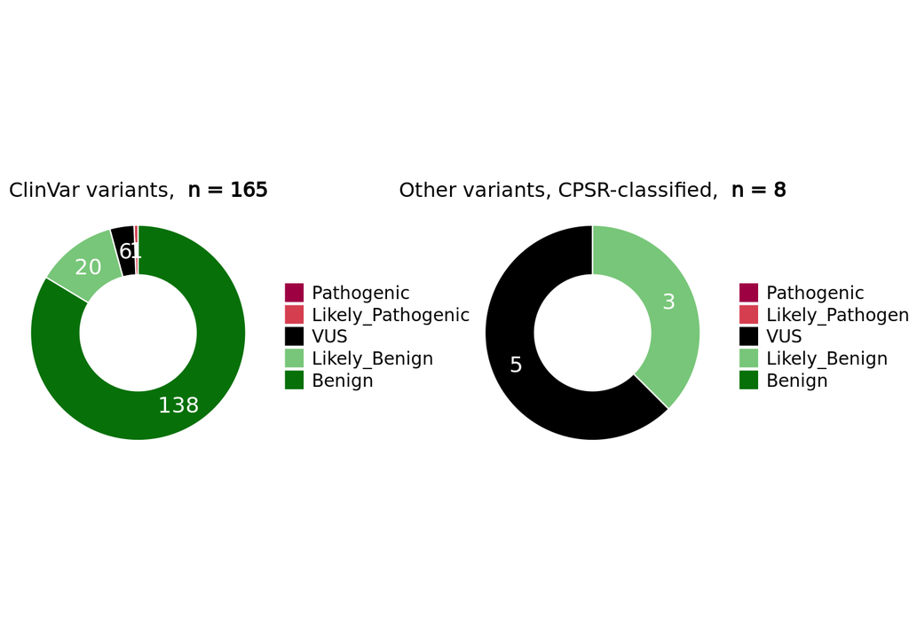

### Variant statistics

Variant numbers in the selected cancer predisposition genes (n = 433)

- Number of SNVs: **200**
- Number of InDels: **8**
- Number of protein-coding variants: **208**

## Variant classification

### Class 5 - **Pathogenic** variants

- A total of n = **0** variants are registered with a *Pathogenic* clinical significance in ClinVar.
- A total of n = **0** **non-ClinVar** variants (i.e. not registered in ClinVar) are classified with a *Pathogenic* significance by CPSR (ACMG criteria - based on population frequency and variant effect).

#### ClinVar

#### Non-ClinVar

### Class 4 - **Likely Pathogenic** variants

- A total of n = **1** variants are recorded with a *Likely Pathogenic* clinical significance in ClinVar.
- A total of n = **0** **non-ClinVar** variants (i.e. not registered in ClinVar) are classified with a *Likely Pathogenic* significance by CPSR (ACMG criteria - based on population frequency and variant effect).

#### ClinVar

Consequence

Genotype

heterozygous

Gene

ClinVar phenotype(s)

ClinVar review status stars

ClinVar conflicting interpretations

MAF gnomAD (Global non-cancer subset)

|  | SYMBOL | CLINVAR_PHENOTYPE | CONSEQUENCE | PROTEIN_CHANGE | GENOTYPE | GENE_NAME | PROTEIN_DOMAIN | HGVSp | HGVSc | NCBI_REFSEQ | CDS_CHANGE | REFSEQ_MRNA | MUTATION_HOTSPOT | RMSK_HIT | PROTEIN_FEATURE | PREDICTED_EFFECT | miRNA_TARGET_HIT | miRNA_TARGET_HIT_PREDICTION | TF_BINDING_SITE_VARIANT | TF_BINDING_SITE_VARIANT_INFO | GERP_SCORE | LOSS_OF_FUNCTION | DBSNP | CLINVAR | CLINVAR_CLASSIFICATION | CLINVAR_REVIEW_STATUS_STARS | CLINVAR_CONFLICTED | CLINVAR_VARIANT_ORIGIN | CPSR_CLASSIFICATION_SOURCE | … |
| --- | --- | --- | --- | --- | --- | --- | --- | --- | --- | --- | --- | --- | --- | --- | --- | --- | --- | --- | --- | --- | --- | --- | --- | --- | --- | --- | --- | --- | --- | --- |
| 1 | MUTYH | Colon cancer; Endometrial cancer; Hereditary cancer-predisposing syndrome; Neoplasm of stomach; Pilomatrixoma; Breast carcinoma; Carcinoma of colon; Small intestine carcinoid; MYH-associated polyposis… | missense_variant, splice_region_variant | p.Gly368Asp | heterozygous | mutY DNA glycosylase | NUDIX domain | ENSP00000407590.2:p.Gly368Asp | ENST00000456914.7:c.1103G>A | NM_001048174 | missense_variant&splice_region_variant:ENST00000456914.7:c.1103G>A:exon13:p.G368D | NM_001048174 |  |  |  | SIFT:Damaging, LRT:Damaging, MutationTaster:Damaging, MutationAssessor:Damaging, FATHMM:Damaging, FATHMM-mkl:Damaging, PROVEAN:Damaging, M-CAP:Damaging, MutPred:NA, GERP++ RS score:5.4, PrimateAI:Tole… |  |  |  |  | 5.4 | False | rs36053993 | Germline - MYH-associated polyposis;Endometrial cancer;not provided;Hereditary cancer-predisposing syndrome;not specified;Carcinoma of colon;Neoplasm of stomach;Small intestine carcinoid;Colorectal ad… | Likely_Pathogenic | 2 | False | germline | ClinVar | … |

#### Non-ClinVar

### Class 3 - Variants of **Uncertain Significance (VUS)**

- A total of n = **6** variants are recorded with a *VUS* clinical significance in ClinVar.
- A total of n = **5** **non-ClinVar** variants (i.e. not registered in ClinVar) are classified with a *VUS* significance by CPSR (ACMG criteria - based on population frequency and variant effect).

#### ClinVar

Consequence

Genotype

heterozygous

homozygous

Gene

Genomic conservation score (GERP)

MAF gnomAD (Global non-cancer subset)

miRNA target gain/loss

TF binding site alteration

ClinVar phenotype(s)

ClinVar review status stars

ClinVar conflicting interpretations

|  | SYMBOL | CLINVAR_PHENOTYPE | CONSEQUENCE | PROTEIN_CHANGE | GENOTYPE | GENE_NAME | PROTEIN_DOMAIN | HGVSp | HGVSc | NCBI_REFSEQ | CDS_CHANGE | REFSEQ_MRNA | MUTATION_HOTSPOT | RMSK_HIT | PROTEIN_FEATURE | PREDICTED_EFFECT | miRNA_TARGET_HIT | miRNA_TARGET_HIT_PREDICTION | TF_BINDING_SITE_VARIANT | TF_BINDING_SITE_VARIANT_INFO | GERP_SCORE | LOSS_OF_FUNCTION | DBSNP | CLINVAR | CLINVAR_CLASSIFICATION | CLINVAR_REVIEW_STATUS_STARS | CLINVAR_CONFLICTED | CLINVAR_VARIANT_ORIGIN | CPSR_CLASSIFICATION_SOURCE | … |
| --- | --- | --- | --- | --- | --- | --- | --- | --- | --- | --- | --- | --- | --- | --- | --- | --- | --- | --- | --- | --- | --- | --- | --- | --- | --- | --- | --- | --- | --- | --- |
| 1 | TYK2 | Immunodeficiency 35 | missense_variant | p.Val526Ile | heterozygous | tyrosine kinase 2 |  | ENSP00000431885.1:p.Val526Ile | ENST00000525621.6:c.1576G>A | NM_001385199, NM_001385205, NM_001385201, NM_001385206, NM_001385207, NM_001385202, NM_001385200, NM_001385198, NM_001385197, NM_003331, NM_001385203, NM_001385204 | missense_variant:ENST00000525621.6:c.1576G>A:exon11:p.V526I | NM_001385199, NM_001385205, NM_001385201, NM_001385206, NM_001385207, NM_001385202, NM_001385200, NM_001385198, NM_001385197, NM_003331, NM_001385203, NM_001385204 |  |  |  | SIFT:Tolerated, LRT:Tolerated, MutationTaster:Tolerated, MutationAssessor:Damaging, FATHMM:Tolerated, FATHMM-mkl:Tolerated, PROVEAN:Tolerated, M-CAP:Tolerated, MutPred:0.29, GERP++ RS score:-0.258, Pr… |  |  |  |  | -0.258 | False | rs758682935 | Germline - Immunodeficiency 35 | VUS | 1 | False | germline | ClinVar | … |
| 2 | RNASEL | Prostate cancer, susceptibility to | missense_variant | p.Arg462Gln | heterozygous | ribonuclease L | Protein kinase domain | ENSP00000356530.3:p.Arg462Gln | ENST00000367559.7:c.1385G>A | NM_021133 | missense_variant:ENST00000367559.7:c.1385G>A:exon2:p.R462Q | NM_021133 |  |  |  | SIFT:Damaging, LRT:Tolerated, MutationTaster:ProbablyDamaging, MutationAssessor:Damaging, FATHMM:Tolerated, FATHMM-mkl:Tolerated, PROVEAN:Tolerated, M-CAP:NA, MutPred:NA, GERP++ RS score:0.0561, Prima… |  |  |  |  | 0.0561 | False | rs486907 | Germline - Prostate cancer, susceptibility to | VUS | 0 | False | germline | ClinVar | … |
| 3 | SDHB | Malignant tumor of breast; Cowden syndrome; Hereditary cancer-predisposing syndrome; Pheochromocytoma; Gastrointestinal stroma tumor; Hereditary Paraganglioma-Pheochromocytoma Syndromes; Carney-Strata… | missense_variant | p.Ser163Pro | heterozygous | succinate dehydrogenase complex iron sulfur subunit B |  | ENSP00000364649.3:p.Ser163Pro | ENST00000375499.8:c.487T>C | NM_003000 | missense_variant:ENST00000375499.8:c.487T>C:exon5:p.S163P | NM_003000 |  |  | REGION:Interaction with SDHAF1:146-218 | SIFT:Tolerated, LRT:Damaging, MutationTaster:Damaging, MutationAssessor:Tolerated, FATHMM:Damaging, FATHMM-mkl:Damaging, PROVEAN:Tolerated, M-CAP:NA, MutPred:NA, GERP++ RS score:5.89, PrimateAI:Tolera… |  |  |  |  | 5.89 | False | rs33927012 | Germline - Cowden syndrome;not provided;not specified;Hereditary cancer-predisposing syndrome;Paragangliomas 4;Gastrointestinal stromal tumor;Pheochromocytoma;Hereditary Paraganglioma-Pheochromocytoma… | VUS | 1 | True | germline | ClinVar | … |
| 4 | RET | Multiple endocrine neoplasia, type 2a; Multiple endocrine neoplasia; Hereditary cancer-predisposing syndrome; Pheochromocytoma; Renal hypodysplasia/aplasia 1; Hirschsprung disease 1; Multiple endocrin… | missense_variant | p.Gly691Ser | heterozygous | ret proto-oncogene |  | ENSP00000347942.3:p.Gly691Ser | ENST00000355710.8:c.2071G>A | NM_020975 | missense_variant:ENST00000355710.8:c.2071G>A:exon11:p.G691S | NM_020975 |  |  |  | SIFT:Tolerated, LRT:Tolerated, MutationTaster:ProbablyDamaging, MutationAssessor:Tolerated, FATHMM:Tolerated, FATHMM-mkl:Tolerated, PROVEAN:Tolerated, M-CAP:NA, MutPred:NA, GERP++ RS score:-1.08, Prim… |  |  |  |  | -1.08 | False | rs1799939 | Germline - not provided;not specified;Hereditary cancer-predisposing syndrome;Renal hypodysplasia/aplasia 1;Hirschsprung disease 1;Pheochromocytoma;Multiple endocrine neoplasia;Multiple endocrine neop… | VUS | 1 | True | germline | ClinVar | … |
| 5 | ERCC5 | not specified | missense_variant | p.Gly1080Arg | homozygous | ERCC excision repair 5, endonuclease |  | ENSP00000498881.2:p.Gly1080Arg | ENST00000652225.2:c.3238G>C | NM_000123 | missense_variant:ENST00000652225.2:c.3238G>C:exon15:p.G1080R | NM_000123 |  |  | REGION:Interaction with ERCC6/CSB:1011-1186, REGION:Disordered:1056-1081 | SIFT:Tolerated, LRT:Tolerated, MutationTaster:ProbablyDamaging, MutationAssessor:Tolerated, FATHMM:Tolerated, FATHMM-mkl:Tolerated, PROVEAN:Tolerated, M-CAP:NA, MutPred:NA, GERP++ RS score:0.141, Prim… |  |  |  |  | 0.141 | False | rs9514067 | Germline - not specified | VUS | 0 | False | germline | ClinVar | … |
| 6 | TG | Iodotyrosyl coupling defect; not provided | missense_variant | p.Arg988His | heterozygous | thyroglobulin |  | ENSP00000220616.4:p.Arg988His | ENST00000220616.9:c.2963G>A | NM_003235 | missense_variant:ENST00000220616.9:c.2963G>A:exon11:p.R988H | NM_003235 |  |  | DISULFID:925-1031:925-1031 | SIFT:Tolerated, LRT:Tolerated, MutationTaster:ProbablyDamaging, MutationAssessor:Damaging, FATHMM:Tolerated, FATHMM-mkl:Tolerated, PROVEAN:Tolerated, M-CAP:NA, MutPred:NA, GERP++ RS score:-0.246, Prim… |  |  |  |  | -0.246 | False | rs16893332 | Germline - not provided;Iodotyrosyl coupling defect | VUS | 1 | True | germline | ClinVar | … |

#### Non-ClinVar

- **IMPORTANT NOTE:** Non-ClinVar variants with a CPSR pathogenicity score of 2.0 (maximum score for VUS in CPSR) represent the most challenging collection of variants when it comes to classification. Based on calibration of classification score thresholds with high-confident ClinVar variants, we discovered a heterogeneous mix of *Likely Pathogenic*, *Pathogenic*, and *VUS* variants that were all attributed with this score. Henceforth, we recommend that these variants should be prioritized for careful examination, and any such cases are conveniently higlighted in the table below.

Consequence

Genotype

heterozygous

homozygous

Gene

Genomic conservation score (GERP)

miRNA target gain/loss

TF binding site alteration

CPSR classification (ACMG criteria codes)

CPSR pathogenicity score

MAF gnomAD (Global non-cancer subset)

|  | SYMBOL | CONSEQUENCE | PROTEIN_CHANGE | GENOTYPE | GENE_NAME | PROTEIN_DOMAIN | HGVSp | HGVSc | NCBI_REFSEQ | CDS_CHANGE | REFSEQ_MRNA | MUTATION_HOTSPOT | RMSK_HIT | PROTEIN_FEATURE | PREDICTED_EFFECT | miRNA_TARGET_HIT | miRNA_TARGET_HIT_PREDICTION | TF_BINDING_SITE_VARIANT | TF_BINDING_SITE_VARIANT_INFO | GERP_SCORE | LOSS_OF_FUNCTION | DBSNP | CPSR_CLASSIFICATION_SOURCE | CPSR_CLASSIFICATION | CPSR_PATHOGENICITY_SCORE | CPSR_CLASSIFICATION_DOC | CPSR_CLASSIFICATION_CODE | ONCOGENE | TUMOR_SUPPRESSOR | … |
| --- | --- | --- | --- | --- | --- | --- | --- | --- | --- | --- | --- | --- | --- | --- | --- | --- | --- | --- | --- | --- | --- | --- | --- | --- | --- | --- | --- | --- | --- | --- |
| 1 | FAT1 | missense_variant | p.Val1043Met | heterozygous | FAT atypical cadherin 1 | Cadherin domain | ENSP00000406229.2:p.Val1043Met | ENST00000441802.7:c.3127G>A | NM_005245 | missense_variant:ENST00000441802.7:c.3127G>A:exon2:p.V1043M | NM_005245 |  |  | TOPO_DOM:Extracellular:22-4181 | SIFT:Damaging, LRT:Damaging, MutationTaster:Damaging, MutationAssessor:Damaging, FATHMM:Tolerated, FATHMM-mkl:Damaging, PROVEAN:Damaging, M-CAP:Damaging, MutPred:NA, GERP++ RS score:4.15, PrimateAI:To… |  |  |  |  | 4.15 | False | rs372605617 | Other | VUS | 1 | - Allele count within pathogenic range (MAF - Missense variant in a gene that has a relatively low rate of benign missense variation (50% of high-confidence pathogenic variants (ClinVar)) | ACMG_PM2_1\|ACMG_PP2 | False | True | … |
| 2 | MSR1 | missense_variant | p.Leu32Val | heterozygous | macrophage scavenger receptor 1 |  | ENSP00000262101.5:p.Leu32Val | ENST00000262101.10:c.94C>G | NM_138715 | missense_variant:ENST00000262101.10:c.94C>G:exon2:p.L32V | NM_138715 |  |  | TOPO_DOM:Cytoplasmic:1-50 | SIFT:Tolerated, LRT:Tolerated, MutationTaster:Tolerated, MutationAssessor:Damaging, FATHMM:Damaging, FATHMM-mkl:Tolerated, PROVEAN:Tolerated, M-CAP:Damaging, MutPred:0.081, GERP++ RS score:1.45, Prima… |  |  |  |  | 1.45 | False | rs758834622 | Other | VUS | 1 | - Allele count within pathogenic range (MAF - Missense variant in a gene that has a relatively low rate of benign missense variation (50% of high-confidence pathogenic variants (ClinVar)) | ACMG_PM2_1\|ACMG_PP2 | False | False | … |
| 3 | JAK3 | splice_donor_region_variant, intron_variant |  | heterozygous | Janus kinase 3 |  |  | ENST00000458235.7:c.861+6G>A | NM_000215 |  | NM_000215 |  |  |  | SIFT:NA, LRT:NA, MutationTaster:NA, MutationAssessor:NA, FATHMM:NA, FATHMM-mkl:NA, PROVEAN:NA, M-CAP:NA, MutPred:NA, GERP++ RS score:NA, PrimateAI:NA, DEOGEN2:NA, LIST-S2:NA, BayesDel:NA, ALoFT:NA, Me… |  |  |  |  | -5.8 | False | rs748305273 | Other | VUS | 0.5 | - Allele count within pathogenic range (MAF <= 0.005% in the population-specific non-cancer gnomAD subset, min AN = 12,000) | ACMG_PM2_1 | False | False | … |
| 4 | POLA1 | missense_variant | p.Arg231Cys | homozygous | DNA polymerase alpha 1, catalytic subunit |  | ENSP00000368358.3:p.Arg231Cys | ENST00000379068.8:c.691C>T |  | missense_variant:ENST00000379068.8:c.691C>T:exon8:p.R231C |  |  |  |  | SIFT:Tolerated, LRT:Tolerated, MutationTaster:Tolerated, MutationAssessor:Tolerated, FATHMM:Tolerated, FATHMM-mkl:Tolerated, PROVEAN:Tolerated, M-CAP:Tolerated, MutPred:0.396, GERP++ RS score:-4.39, P… |  |  |  |  | -4.39 | False | rs750378412 | Other | VUS | 0 | - Allele count within pathogenic range (MAF - Missense variant in a gene that has a relatively low rate of benign missense variation (50% of high-confidence pathogenic variants (ClinVar))- Multiple li… | ACMG_PM2_1\|ACMG_PP2\|ACMG_BP4 | False | False | … |
| 5 | CBFA2T3 | missense_variant | p.Gln163Arg | heterozygous | CBFA2/RUNX1 partner transcriptional co-repressor 3 |  | ENSP00000268679.4:p.Gln163Arg | ENST00000268679.9:c.488A>G | NM_005187 | missense_variant:ENST00000268679.9:c.488A>G:exon4:p.Q163R | NM_005187 |  |  | REGION:Mediates localization to the nucleus:1-435, REGION:Mediates interaction with PDE7A (in isoform 2):1-430, REGION:Interaction with ZBTB33:145-242 | SIFT:Damaging, LRT:Damaging, MutationTaster:Damaging, MutationAssessor:Damaging, FATHMM:Tolerated, FATHMM-mkl:Damaging, PROVEAN:Damaging, M-CAP:Damaging, MutPred:NA, GERP++ RS score:4.33, PrimateAI:To… |  |  |  |  | 4.33 | False | rs148437643 | Other | VUS | -0.5 | - Somewhat high MAF (> 0.005% in gnomAD non-cancer pop subset, min AN = 12,000) - recessive mode of inheritance- Missense variant in a gene that has a relatively low rate of benign missense variation … | ACMG_BS1_2_AR\|ACMG_PP2 | False | True | … |

### Class 2 - **Likely Benign** variants

- A total of n = **20** variants are recorded with a *Likely Benign* clinical significance in ClinVar.
- A total of n = **3** **Other** variants (i.e. not registered in ClinVar) are classified with a *Likely Benign* significance by CPSR (ACMG criteria - based on population frequency and variant effect).

#### ClinVar

Consequence

Genotype

heterozygous

homozygous

Gene

ClinVar phenotype(s)

ClinVar review status stars

ClinVar conflicting interpretations

MAF gnomAD (Global non-cancer subset)

|  | SYMBOL | CLINVAR_PHENOTYPE | CONSEQUENCE | PROTEIN_CHANGE | GENOTYPE | GENE_NAME | PROTEIN_DOMAIN | HGVSp | HGVSc | NCBI_REFSEQ | CDS_CHANGE | REFSEQ_MRNA | MUTATION_HOTSPOT | RMSK_HIT | PROTEIN_FEATURE | PREDICTED_EFFECT | miRNA_TARGET_HIT | miRNA_TARGET_HIT_PREDICTION | TF_BINDING_SITE_VARIANT | TF_BINDING_SITE_VARIANT_INFO | GERP_SCORE | LOSS_OF_FUNCTION | DBSNP | CLINVAR | CLINVAR_CLASSIFICATION | CLINVAR_REVIEW_STATUS_STARS | CLINVAR_CONFLICTED | CLINVAR_VARIANT_ORIGIN | CPSR_CLASSIFICATION_SOURCE | … |
| --- | --- | --- | --- | --- | --- | --- | --- | --- | --- | --- | --- | --- | --- | --- | --- | --- | --- | --- | --- | --- | --- | --- | --- | --- | --- | --- | --- | --- | --- | --- |
| 1 | PRF1 | Familial hemophagocytic lymphohistiocytosis 2 | missense_variant | p.Ala211Val | heterozygous | perforin 1 | MAC/Perforin domain | ENSP00000398568.1:p.Ala211Val | ENST00000441259.2:c.632C>T | NM_005041, NM_001083116 | missense_variant:ENST00000441259.2:c.632C>T:exon3:p.A211V | NM_005041, NM_001083116 |  |  |  | SIFT:Tolerated, LRT:Tolerated, MutationTaster:Tolerated, MutationAssessor:Damaging, FATHMM:Damaging, FATHMM-mkl:Tolerated, PROVEAN:Tolerated, M-CAP:NA, MutPred:NA, GERP++ RS score:0.208, PrimateAI:Tol… |  |  |  |  | 0.208 | False | rs368524364 | Germline - Familial hemophagocytic lymphohistiocytosis 2 | Likely_Benign | 2 | False | germline | ClinVar | … |
| 2 | MSH3 | Megaloblastic anemia due to dihydrofolate reductase deficiency; Familial adenomatous polyposis 4; not provided | inframe_deletion | p.Ala57_Ala62del | homozygous | mutS homolog 3 |  | ENSP00000265081.6:p.Ala57_Ala62del | ENST00000265081.7:c.162_179del | NM_002439 | inframe_deletion:ENST00000265081.7:c.162_179del:exon1:p.A57_A62del | NM_002439 |  |  |  |  |  |  |  |  | 0 | False | rs201874762 | Germline - not provided;Familial adenomatous polyposis 4;Megaloblastic anemia due to dihydrofolate reductase deficiency | Likely_Benign | 2 | False | germline | ClinVar | … |
| 3 | KIT | Mastocytosis; Hereditary cancer-predisposing syndrome; Partial albinism; Gastrointestinal stroma tumor; not specified; not provided | missense_variant | p.Met541Leu | heterozygous | KIT proto-oncogene, receptor tyrosine kinase |  | ENSP00000288135.6:p.Met541Leu | ENST00000288135.6:c.1621A>C | NM_000222 | missense_variant:ENST00000288135.6:c.1621A>C:exon10:p.M541L | NM_000222 |  |  | TRANSMEM:Helical:525-545 | SIFT:Tolerated, LRT:Tolerated, MutationTaster:Tolerated, MutationAssessor:Tolerated, FATHMM:Tolerated, FATHMM-mkl:Damaging, PROVEAN:Tolerated, M-CAP:NA, MutPred:NA, GERP++ RS score:1.82, PrimateAI:Tol… |  |  |  |  | 1.82 | False | rs3822214 | Germline,somatic - not provided;not specified;Mastocytosis;Partial albinism;Gastrointestinal stromal tumor;Chronic myelogenous leukemia, BCR-ABL1 positive;Hereditary cancer-predisposing syndrome;Lip a… | Likely_Benign | 2 | False | germline,somatic | ClinVar | … |
| 4 | FANCF | Malignant tumor of breast; Fanconi anemia; Fanconi anemia, complementation group F; not specified; not provided | missense_variant | p.Ala186Val | heterozygous | FA complementation group F | Fanconi anemia group F protein (FANCF) | ENSP00000330875.3:p.Ala186Val | ENST00000327470.6:c.557C>T | NM_022725 | missense_variant:ENST00000327470.6:c.557C>T:exon1:p.A186V | NM_022725 |  |  |  | SIFT:Tolerated, LRT:Tolerated, MutationTaster:Tolerated, MutationAssessor:Tolerated, FATHMM:Tolerated, FATHMM-mkl:Tolerated, PROVEAN:Tolerated, M-CAP:NA, MutPred:NA, GERP++ RS score:1.82, PrimateAI:To… |  |  |  |  | 1.82 | False | rs113910234 | Germline - not specified;Fanconi anemia, complementation group F;Fanconi anemia;Malignant tumor of breast;not provided | Likely_Benign | 2 | False | germline | ClinVar | … |
| 5 | RAD51C | Malignant tumor of breast; Hereditary cancer-predisposing syndrome; Fanconi anemia, complementation group O; Breast-ovarian cancer, familial 3; not specified; Breast and/or ovarian cancer; not provide… | missense_variant | p.Ala126Thr | heterozygous | RAD51 paralog C | Rad51 | ENSP00000336701.4:p.Ala126Thr | ENST00000337432.9:c.376G>A | NM_058216 | missense_variant:ENST00000337432.9:c.376G>A:exon2:p.A126T | NM_058216 |  |  | REGION:Required for Holliday junction resolution activity:1-126, REGION:Interaction with RAD51B, RAD51D and XRCC3:79-136, NP_BIND:ATP:125-132 | SIFT:Tolerated, LRT:Tolerated, MutationTaster:Damaging, MutationAssessor:Damaging, FATHMM:Tolerated, FATHMM-mkl:Damaging, PROVEAN:Tolerated, M-CAP:Tolerated, MutPred:NA, GERP++ RS score:3.35, PrimateA… |  |  |  |  | 3.35 | False | rs61758784 | Germline - Fanconi anemia, complementation group O;Hereditary cancer-predisposing syndrome;not specified;Breast-ovarian cancer, familial 3;not provided;none provided;Malignant tumor of breast;Breast a… | Likely_Benign | 2 | False | germline | ClinVar | … |
| 6 | ERCC2 | Xeroderma pigmentosum, group D; Cerebrooculofacioskeletal syndrome 2; Trichothiodystrophy 1, photosensitive; not specified; not provided | missense_variant | p.Asp312Asn | homozygous | ERCC excision repair 2, TFIIH core complex helicase subunit | Helical and beta-bridge domain | ENSP00000375809.4:p.Asp312Asn | ENST00000391945.10:c.934G>A | NM_000400 | missense_variant:ENST00000391945.10:c.934G>A:exon10:p.D312N | NM_000400 |  |  |  | SIFT:Tolerated, LRT:Damaging, MutationTaster:ProbablyDamaging, MutationAssessor:Tolerated, FATHMM:Tolerated, FATHMM-mkl:Damaging, PROVEAN:Damaging, M-CAP:NA, MutPred:NA, GERP++ RS score:5.15, PrimateA… |  |  |  |  | 5.15 | False | rs1799793 | Germline - not specified;Xeroderma pigmentosum, group D;not provided;Cerebrooculofacioskeletal syndrome 2;Trichothiodystrophy 1, photosensitive | Likely_Benign | 2 | False | germline | ClinVar | … |
| 7 | FAS | Autoimmune lymphoproliferative syndrome type 1; not specified; not provided | missense_variant | p.Ala16Thr | heterozygous | Fas cell surface death receptor |  | ENSP00000498466.1:p.Ala16Thr | ENST00000652046.1:c.46G>A | NM_000043 | missense_variant:ENST00000652046.1:c.46G>A:exon2:p.A16T | NM_000043 |  |  | SIGNAL:signal peptide_1-25:1-25 | SIFT:Damaging, LRT:Tolerated, MutationTaster:ProbablyDamaging, MutationAssessor:Tolerated, FATHMM:NA, FATHMM-mkl:Tolerated, PROVEAN:Tolerated, M-CAP:NA, MutPred:NA, GERP++ RS score:-1.88, PrimateAI:To… |  |  |  |  | -1.88 | False | rs3218619 | Germline - not specified;Autoimmune lymphoproliferative syndrome type 1;not provided | Likely_Benign | 2 | False | germline | ClinVar | … |
| 8 | ERCC2 | Xeroderma pigmentosum, group D; Cerebrooculofacioskeletal syndrome 2; Trichothiodystrophy 1, photosensitive; not specified; not provided | missense_variant | p.Lys751Gln | homozygous | ERCC excision repair 2, TFIIH core complex helicase subunit |  | ENSP00000375809.4:p.Lys751Gln | ENST00000391945.10:c.2251A>C | NM_000400 | missense_variant:ENST00000391945.10:c.2251A>C:exon23:p.K751Q | NM_000400 |  |  |  | SIFT:Tolerated, LRT:Tolerated, MutationTaster:ProbablyDamaging, MutationAssessor:Tolerated, FATHMM:NA, FATHMM-mkl:Tolerated, PROVEAN:Tolerated, M-CAP:NA, MutPred:NA, GERP++ RS score:4.29, PrimateAI:To… |  |  |  |  | 4.29 | False | rs13181 | Germline,somatic - not specified;Xeroderma pigmentosum, group D;Non-small cell lung carcinoma;Bone osteosarcoma;not provided;Cerebrooculofacioskeletal syndrome 2;Trichothiodystrophy 1, photosensitive | Likely_Benign | 2 | False | germline,somatic | ClinVar | … |
| 9 | ANKRD26 | Thrombocytopenia 2; not provided | missense_variant, splice_region_variant | p.Val1219Ile | heterozygous | ankyrin repeat domain 26 |  | ENSP00000365255.4:p.Val1219Ile | ENST00000376087.5:c.3655G>A | NM_014915 | missense_variant&splice_region_variant:ENST00000376087.5:c.3655G>A:exon25:p.V1219I | NM_014915 |  |  | COILED:coiled-coil region_905-1472:905-1472 | SIFT:NA, LRT:Tolerated, MutationTaster:Tolerated, MutationAssessor:NA, FATHMM:Tolerated, FATHMM-mkl:Tolerated, PROVEAN:Tolerated, M-CAP:Tolerated, MutPred:NA, GERP++ RS score:4.51, PrimateAI:Tolerated… |  |  |  |  | 4.51 | False | rs146819984 | Germline - Thrombocytopenia 2;not provided | Likely_Benign | 2 | False | germline | ClinVar | … |
| 10 | FANCA | Fanconi anemia; Fanconi anemia, complementation group A; not specified; not provided | missense_variant | p.Ser858Arg | heterozygous | FA complementation group A |  | ENSP00000373952.3:p.Ser858Arg | ENST00000389301.8:c.2574C>G | NM_000135 | missense_variant:ENST00000389301.8:c.2574C>G:exon27:p.S858R | NM_000135 |  |  |  | SIFT:Tolerated, LRT:Tolerated, MutationTaster:Tolerated, MutationAssessor:Damaging, FATHMM:Damaging, FATHMM-mkl:Tolerated, PROVEAN:Tolerated, M-CAP:NA, MutPred:NA, GERP++ RS score:1.56, PrimateAI:Tole… |  |  |  |  | 1.56 | False | rs17233141 | Germline - not specified;Fanconi anemia, complementation group A;Fanconi anemia;not provided | Likely_Benign | 2 | False | germline | ClinVar | … |

[output cut: 10 more lines]

#### Non-ClinVar

Consequence

Genotype

heterozygous

Gene

CPSR classification (ACMG criteria codes)

CPSR pathogenicity score

MAF gnomAD (Global non-cancer subset)

|  | SYMBOL | CONSEQUENCE | PROTEIN_CHANGE | GENOTYPE | GENE_NAME | PROTEIN_DOMAIN | HGVSp | HGVSc | NCBI_REFSEQ | CDS_CHANGE | REFSEQ_MRNA | MUTATION_HOTSPOT | RMSK_HIT | PROTEIN_FEATURE | PREDICTED_EFFECT | miRNA_TARGET_HIT | miRNA_TARGET_HIT_PREDICTION | TF_BINDING_SITE_VARIANT | TF_BINDING_SITE_VARIANT_INFO | GERP_SCORE | LOSS_OF_FUNCTION | DBSNP | CPSR_CLASSIFICATION_SOURCE | CPSR_CLASSIFICATION | CPSR_PATHOGENICITY_SCORE | CPSR_CLASSIFICATION_DOC | CPSR_CLASSIFICATION_CODE | ONCOGENE | TUMOR_SUPPRESSOR | … |
| --- | --- | --- | --- | --- | --- | --- | --- | --- | --- | --- | --- | --- | --- | --- | --- | --- | --- | --- | --- | --- | --- | --- | --- | --- | --- | --- | --- | --- | --- | --- |
| 1 | RING1 | missense_variant | p.Ala195Thr | heterozygous | ring finger protein 1 |  | ENSP00000363787.4:p.Ala195Thr | ENST00000374656.5:c.583G>A | NM_002931 | missense_variant:ENST00000374656.5:c.583G>A:exon5:p.A195T | NM_002931 |  |  |  | SIFT:Tolerated, LRT:Tolerated, MutationTaster:Damaging, MutationAssessor:Tolerated, FATHMM:Damaging, FATHMM-mkl:Damaging, PROVEAN:Tolerated, M-CAP:Tolerated, MutPred:NA, GERP++ RS score:1.29, PrimateA… |  |  |  |  | 1.29 | False | rs149445528 | Other | Likely_Benign | -1.5 | - Somewhat high MAF (> 0.005% in gnomAD non-cancer pop subset, min AN = 12,000) - recessive mode of inheritance- Missense variant in a gene that has a relatively low rate of benign missense variation … | ACMG_BS1_2_AR\|ACMG_PP2\|ACMG_BP4 | False | False | … |
| 2 | KLLN | missense_variant | p.Trp149Arg | heterozygous | killin, p53 regulated DNA replication inhibitor |  | ENSP00000392204.2:p.Trp149Arg | ENST00000445946.5:c.445T>A | NM_001126049 | missense_variant:ENST00000445946.5:c.445T>A:exon1:p.W149R | NM_001126049 |  |  |  | SIFT:Damaging, LRT:NA, MutationTaster:Tolerated, MutationAssessor:Tolerated, FATHMM:NA, FATHMM-mkl:Tolerated, PROVEAN:Damaging, M-CAP:NA, MutPred:NA, GERP++ RS score:0.222, PrimateAI:Tolerated, DEOGEN… |  |  |  |  | 0.222 | False | rs144811392 | Other | Likely_Benign | -3.5 | - High MAF (> 0.3% in gnomAD non-cancer pop subset, min AN = 12,000) - recessive mode of inheritance- Missense variant in a gene that has a relatively low rate of benign missense variation (50% of hig… | ACMG_BS1_1_AR\|ACMG_PP2\|ACMG_BP4 | False | False | … |
| 3 | KLLN | missense_variant | p.Asn131Ser | heterozygous | killin, p53 regulated DNA replication inhibitor |  | ENSP00000392204.2:p.Asn131Ser | ENST00000445946.5:c.392A>G | NM_001126049 | missense_variant:ENST00000445946.5:c.392A>G:exon1:p.N131S | NM_001126049 |  |  |  | SIFT:Tolerated, LRT:NA, MutationTaster:Tolerated, MutationAssessor:Tolerated, FATHMM:NA, FATHMM-mkl:Tolerated, PROVEAN:Tolerated, M-CAP:NA, MutPred:NA, GERP++ RS score:1.31, PrimateAI:Tolerated, DEOGE… |  |  |  |  | 1.31 | False | rs147932146 | Other | Likely_Benign | -3.5 | - High MAF (> 0.3% in gnomAD non-cancer pop subset, min AN = 12,000) - recessive mode of inheritance- Missense variant in a gene that has a relatively low rate of benign missense variation (50% of hig… | ACMG_BS1_1_AR\|ACMG_PP2\|ACMG_BP4 | False | False | … |

### Class 1 - **Benign** variants

- A total of n = **138** variants are recorded with a *Benign* clinical significance in ClinVar.
- A total of n = **0** **Other** variants (i.e. not registered in ClinVar) are classified with a *Benign* significance by CPSR (ACMG criteria - based on population frequency and variant effect).

#### ClinVar

Consequence

Genotype

heterozygous

homozygous

Gene

ClinVar phenotype(s)

ClinVar review status stars

ClinVar conflicting interpretations

MAF gnomAD (Global non-cancer subset)

|  | SYMBOL | CLINVAR_PHENOTYPE | CONSEQUENCE | PROTEIN_CHANGE | GENOTYPE | GENE_NAME | PROTEIN_DOMAIN | HGVSp | HGVSc | NCBI_REFSEQ | CDS_CHANGE | REFSEQ_MRNA | MUTATION_HOTSPOT | RMSK_HIT | PROTEIN_FEATURE | PREDICTED_EFFECT | miRNA_TARGET_HIT | miRNA_TARGET_HIT_PREDICTION | TF_BINDING_SITE_VARIANT | TF_BINDING_SITE_VARIANT_INFO | GERP_SCORE | LOSS_OF_FUNCTION | DBSNP | CLINVAR | CLINVAR_CLASSIFICATION | CLINVAR_REVIEW_STATUS_STARS | CLINVAR_CONFLICTED | CLINVAR_VARIANT_ORIGIN | CPSR_CLASSIFICATION_SOURCE | … |
| --- | --- | --- | --- | --- | --- | --- | --- | --- | --- | --- | --- | --- | --- | --- | --- | --- | --- | --- | --- | --- | --- | --- | --- | --- | --- | --- | --- | --- | --- | --- |
| 1 | KLLN | not specified; not provided | missense_variant | p.Arg128Gly | heterozygous | killin, p53 regulated DNA replication inhibitor |  | ENSP00000392204.2:p.Arg128Gly | ENST00000445946.5:c.382C>G | NM_001126049 | missense_variant:ENST00000445946.5:c.382C>G:exon1:p.R128G | NM_001126049 |  |  |  | SIFT:Damaging, LRT:NA, MutationTaster:Tolerated, MutationAssessor:Tolerated, FATHMM:NA, FATHMM-mkl:Tolerated, PROVEAN:Damaging, M-CAP:NA, MutPred:NA, GERP++ RS score:2.44, PrimateAI:Tolerated, DEOGEN2… |  |  |  |  | 2.44 | False | rs201652303 | Germline - not specified;not provided | Benign | 1 | False | germline | ClinVar | … |
| 2 | PRDM1 | not specified; not provided | missense_variant | p.Asp203Glu | heterozygous | PR/SET domain 1 |  | ENSP00000358092.4:p.Asp203Glu | ENST00000369096.9:c.609C>G | NM_001198 | missense_variant:ENST00000369096.9:c.609C>G:exon4:p.D203E | NM_001198 |  |  |  | SIFT:Tolerated, LRT:Damaging, MutationTaster:ProbablyDamaging, MutationAssessor:Damaging, FATHMM:Damaging, FATHMM-mkl:Damaging, PROVEAN:Tolerated, M-CAP:NA, MutPred:NA, GERP++ RS score:5.94, PrimateAI… |  |  |  |  | 5.94 | False | rs811925 | Germline - not specified;not provided | Benign | 1 | False | germline | ClinVar | … |
| 3 | TBXT | not provided | missense_variant | p.Gly177Asp | heterozygous | T-box transcription factor T | T-box | ENSP00000355841.3:p.Gly177Asp | ENST00000366876.7:c.530G>A |  | missense_variant:ENST00000366876.7:c.530G>A:exon3:p.G177D |  |  |  |  | SIFT:NA, LRT:Damaging, MutationTaster:ProbablyDamaging, MutationAssessor:NA, FATHMM:Tolerated, FATHMM-mkl:Damaging, PROVEAN:Damaging, M-CAP:NA, MutPred:NA, GERP++ RS score:4.06, PrimateAI:Damaging, DE… |  |  |  |  | 4.06 | False | rs2305089 | Germline - not provided | Benign | 2 | False | germline | ClinVar | … |
| 4 | FLT3 | not specified; not provided | missense_variant | p.Thr227Met | heterozygous | fms related receptor tyrosine kinase 3 |  | ENSP00000241453.7:p.Thr227Met | ENST00000241453.12:c.680C>T | NM_004119 | missense_variant:ENST00000241453.12:c.680C>T:exon6:p.T227M | NM_004119 |  |  | TOPO_DOM:Extracellular:27-543 | SIFT:Damaging, LRT:Damaging, MutationTaster:ProbablyDamaging, MutationAssessor:Tolerated, FATHMM:Tolerated, FATHMM-mkl:Damaging, PROVEAN:Tolerated, M-CAP:NA, MutPred:NA, GERP++ RS score:3.85, PrimateA… |  |  |  |  | 3.85 | False | rs1933437 | Germline - not specified;not provided | Benign | 1 | False | germline | ClinVar | … |
| 5 | MUTYH | not provided | splice_donor_5th_base_variant, intron_variant |  | homozygous | mutY DNA glycosylase |  |  | ENST00000456914.7:c.-7+5C>G | NM_001048174 |  | NM_001048174 |  |  |  |  |  |  |  |  | -3.33 | False | rs3219468 | Germline - not provided | Benign | 1 | False | germline | ClinVar | … |
| 6 | MSH2 | not specified; not provided | missense_variant | p.Gln915Arg | heterozygous | mutS homolog 2 |  | ENSP00000384199.1:p.Gln915Arg | ENST00000406134.5:c.2744A>G |  | missense_variant:ENST00000406134.5:c.2744A>G:exon16:p.Q915R |  |  |  | REGION:Disordered:902-921 | SIFT:Damaging, LRT:NA, MutationTaster:ProbablyDamaging, MutationAssessor:NA, FATHMM:Damaging, FATHMM-mkl:Tolerated, PROVEAN:Tolerated, M-CAP:NA, MutPred:NA, GERP++ RS score:-3.02, PrimateAI:NA, DEOGEN… |  |  |  |  | -3.02 | False | rs2303424 | Germline - not provided;not specified | Benign | 0 | False | germline | ClinVar | … |
| 7 | PDGFRB | Infantile myofibromatosis; Premature aging syndrome, Penttinen type; Basal ganglia calcification, idiopathic, 4; Kosaki overgrowth syndrome; not specified; not provided | splice_donor_region_variant, intron_variant |  | heterozygous | platelet derived growth factor receptor beta |  |  | ENST00000261799.9:c.3137+4A>G | NM_001355016, NM_002609, NM_001355017 |  | NM_001355016, NM_002609, NM_001355017 |  |  |  | SIFT:NA, LRT:NA, MutationTaster:NA, MutationAssessor:NA, FATHMM:NA, FATHMM-mkl:NA, PROVEAN:NA, M-CAP:NA, MutPred:NA, GERP++ RS score:NA, PrimateAI:NA, DEOGEN2:NA, LIST-S2:NA, BayesDel:NA, ALoFT:NA, Me… |  |  |  |  | -1.44 | False | rs246391 | Germline - not specified;Premature aging syndrome, Penttinen type;Basal ganglia calcification, idiopathic, 4;Infantile myofibromatosis;Kosaki overgrowth syndrome;not provided | Benign | 2 | False | germline | ClinVar | … |
| 8 | SASH1 | not provided | inframe_insertion | p.Glu22_Pro23dup | heterozygous | SAM and SH3 domain containing 1 |  | ENSP00000356437.3:p.Glu22_Pro23dup | ENST00000367467.8:c.51_56dup | NM_001346505, NM_001346506, NM_015278 | inframe_insertion:ENST00000367467.8:c.51_56dup:exon1:p.E22_P23dup | NM_001346505, NM_001346506, NM_015278 |  | (CCGGAG)n\|Simple_repeat\|Simple_repeat |  |  |  |  |  |  | -8.78 | False | rs76317765 | Germline - not provided | Benign | 1 | False | germline | ClinVar | … |
| 9 | ERCC5 | Xeroderma pigmentosum, group G; not specified | missense_variant | p.Gly1053Arg | homozygous | ERCC excision repair 5, endonuclease |  | ENSP00000498881.2:p.Gly1053Arg | ENST00000652225.2:c.3157G>C | NM_000123 | missense_variant:ENST00000652225.2:c.3157G>C:exon15:p.G1053R | NM_000123 |  |  | REGION:Interaction with ERCC6/CSB:1011-1186 | SIFT:NA, LRT:Tolerated, MutationTaster:ProbablyDamaging, MutationAssessor:Damaging, FATHMM:Tolerated, FATHMM-mkl:Damaging, PROVEAN:Tolerated, M-CAP:NA, MutPred:NA, GERP++ RS score:4.28, PrimateAI:NA, … |  |  |  |  | 4.28 | False | rs9514066 | Germline - not specified;Xeroderma pigmentosum, group G | Benign | 1 | False | germline | ClinVar | … |
| 10 | ERCC5 | Xeroderma pigmentosum, group G; Cerebrooculofacioskeletal syndrome 3; not specified; not provided | missense_variant | p.Asp1104His | heterozygous | ERCC excision repair 5, endonuclease |  | ENSP00000498881.2:p.Asp1104His | ENST00000652225.2:c.3310G>C | NM_000123 | missense_variant:ENST00000652225.2:c.3310G>C:exon15:p.D1104H | NM_000123 |  |  | REGION:Interaction with ERCC6/CSB:1011-1186, REGION:Disordered:1095-1186 | SIFT:NA, LRT:Tolerated, MutationTaster:ProbablyDamaging, MutationAssessor:Damaging, FATHMM:Tolerated, FATHMM-mkl:Damaging, PROVEAN:Damaging, M-CAP:NA, MutPred:NA, GERP++ RS score:4.11, PrimateAI:NA, D… |  |  |  |  | 4.11 | False | rs17655 | Germline - not specified;Xeroderma pigmentosum, group G;Cerebrooculofacioskeletal syndrome 3;not provided | Benign | 2 | False | germline | ClinVar | … |

[output cut: 128 more lines]

#### Non-ClinVar

### Biomarkers

- Variants (**class 4/5**) in the query sample that overlap with reported clinical biomarkers from the [database for clinical interpretations of variants in cancer, CIViC](https://civic.genome.wustl.edu/#/home) are considered. Note that several variants in the query can overlap the same existing biomarker, given that biomarkers are reported at different resolutions (variant/gene level). Total number of clinical evidence items that coincide with query variants:
  - Predisposing: **2** evidence items
  - Predictive: **3** evidence items
  - Prognostic: **2** evidence items
  - Diagnostic: **1** evidence items

**NOTE:** Reported biomarkers in CIViC are mapped at different resolutions (i.e. filter **Biomarker mapping**). The accuracy of a match between variants in the tumor sample and the reported biomarkers will vary accordingly (highlighted by gene symbols with different color backgrounds):

- Biomarker match at the exact variant/codon level
- Biomarker match at the exon/gene level

#### Predisposing

Cancer type

Clinical significance

Evidence level

Gene

Biomarker mapping

The table below lists all variant-evidence item associations:

|  | SYMBOL | GENE_NAME | CANCER_TYPE | CLINICAL_SIGNIFICANCE | EVIDENCE_LEVEL | RATING | EVIDENCE_DIRECTION | CITATION | THERAPEUTIC_CONTEXT | EVIDENCE_TYPE | DESCRIPTION | BIOMARKER_MAPPING | CDS_CHANGE | LOSS_OF_FUNCTION | GENOMIC_CHANGE |
| --- | --- | --- | --- | --- | --- | --- | --- | --- | --- | --- | --- | --- | --- | --- | --- |
| 1 | SH2B3 | SH2B adaptor protein 3 | Colorectal Cancer | Positive | B: Clinical evidence | 2 | Supports | Cheng et al., 2015, Sci Rep |  | Predisposing | A genome wide association study (GWAS) meta-analysis of 13,265 cancer cases (colorectal cancer and endometrial cancer) and 40,245 controls found this variant to be associated with colorectal cancer (O… | exact | missense_variant:ENST00000341259.7:c.784T>C:exon3:p.W262R | False | 12:g.111446804T>C |
| 2 | TP53 | tumor protein p53 | Breast Cancer | Positive | B: Clinical evidence | 4 | Does Not Support | Schmidt et al., 2007, Cancer Res. |  | Predisposing | Large meta-analysis of 5,191 breast cancer patients and 3,834 controls did not find a conclusive link between codon 72 allele and breast cancer susceptibility. Odds ratios were 0.98 (95% CI, 0.91–1.05… | exact | missense_variant:ENST00000269305.9:c.215C>G:exon4:p.P72R | False | 17:g.7676154G>C |

#### Predictive

Cancer type

Clinical significance

Evidence level

Gene

Biomarker mapping

Therapeutic context

The table below lists all variant-evidence item associations:

|  | SYMBOL | GENE_NAME | CANCER_TYPE | CLINICAL_SIGNIFICANCE | EVIDENCE_LEVEL | RATING | EVIDENCE_DIRECTION | CITATION | THERAPEUTIC_CONTEXT | EVIDENCE_TYPE | DESCRIPTION | BIOMARKER_MAPPING | CDS_CHANGE | LOSS_OF_FUNCTION | GENOMIC_CHANGE |
| --- | --- | --- | --- | --- | --- | --- | --- | --- | --- | --- | --- | --- | --- | --- | --- |
| 1 | ERCC2 | ERCC excision repair 2, TFIIH core complex helicase subunit | Lung Non-small Cell Carcinoma | Sensitivity/Response | B: Clinical evidence | 3 | Supports | Gandara et al., 2009, J. Clin. Oncol. | Carboplatin, Paclitaxel | Predictive | The ERCC2 K751Q variant is significantly correlated with increased response to paclitaxel and carboplatin therapies in non small cell lung cancer (NSCLC). The researchers utilized data from three prev… | exact | missense_variant:ENST00000391945.10:c.2251A>C:exon23:p.K751Q | False | 19:g.45351661T>G |
| 2 | FLT3 | fms related receptor tyrosine kinase 3 | Renal Cell Carcinoma | Adverse Response | B: Clinical evidence | 3 | Supports | van Erp et al., 2009, J. Clin. Oncol. | Sunitinib | Predictive | In 219 patients with mostly Renal Cell Carcinoma and some Gastrointestinal Stromal tumors given sunitinib treatment, FLT3 T227M (rs1933437) was associated with the development of leukopenia. 95% confi… | exact | missense_variant:ENST00000241453.12:c.680C>T:exon6:p.T227M | False | 13:g.28050157G>A |
| 3 | ERCC2 | ERCC excision repair 2, TFIIH core complex helicase subunit | Osteosarcoma | Resistance | B: Clinical evidence | 4 | Supports | Caronia et al., 2009, Pharmacogenomics J. | Cisplatin | Predictive | The ERCC2 K751Q variant was significantly correlated with a lower response to cisplatin chemotherapy in osteosarcoma patients and shorter event-free survival. 91 osteosarcoma patients with a median ag… | exact | missense_variant:ENST00000391945.10:c.2251A>C:exon23:p.K751Q | False | 19:g.45351661T>G |

#### Prognostic

Gene

Cancer type

Clinical significance

Evidence level

Biomarker mapping

The table below lists all variant-evidence item associations:

|  | SYMBOL | GENE_NAME | CANCER_TYPE | CLINICAL_SIGNIFICANCE | EVIDENCE_LEVEL | RATING | EVIDENCE_DIRECTION | CITATION | THERAPEUTIC_CONTEXT | EVIDENCE_TYPE | DESCRIPTION | BIOMARKER_MAPPING | CDS_CHANGE | LOSS_OF_FUNCTION | GENOMIC_CHANGE |
| --- | --- | --- | --- | --- | --- | --- | --- | --- | --- | --- | --- | --- | --- | --- | --- |
| 1 | TP53 | tumor protein p53 | Cervical Cancer | Poor Outcome | B: Clinical evidence | 2 | Does Not Support | Klug et al., 2001, Cancer Epidemiol. Biomarkers Prev. |  | Prognostic | In a relatively small meta-analysis of 119 women with cervical cancer and 127 controls, associations with homozygosity for arginine, and heterozygosity at this locus were both associated with odds rat… | exact | missense_variant:ENST00000269305.9:c.215C>G:exon4:p.P72R | False | 17:g.7676154G>C |
| 2 | TP53 | tumor protein p53 | Lung Carcinoma | Poor Outcome | B: Clinical evidence | 3 | Does Not Support | Matakidou et al., 2003, Mutagenesis |  | Prognostic | Pooled data from 13 studies of patients with lung cancer found little effect of codon 72 allele on the overall survival of patients with lung cancer. Proline homozygous patients were correlated with s… | exact | missense_variant:ENST00000269305.9:c.215C>G:exon4:p.P72R | False | 17:g.7676154G>C |

#### Diagnostic

Gene

Cancer type

Clinical association

Evidence level

Biomarker mapping

The table below lists all variant-evidence item associations:

|  | SYMBOL | GENE_NAME | CANCER_TYPE | CLINICAL_SIGNIFICANCE | EVIDENCE_LEVEL | RATING | EVIDENCE_DIRECTION | CITATION | THERAPEUTIC_CONTEXT | EVIDENCE_TYPE | DESCRIPTION | BIOMARKER_MAPPING | CDS_CHANGE | LOSS_OF_FUNCTION | GENOMIC_CHANGE |
| --- | --- | --- | --- | --- | --- | --- | --- | --- | --- | --- | --- | --- | --- | --- | --- |
| 1 | KIT | KIT proto-oncogene, receptor tyrosine kinase | Chronic Myeloid Leukemia | Positive | B: Clinical evidence | 4 | Does Not Support | Krüger et al., 2006, Leukemia |  | Diagnostic | M541L mutation was not associated with CML in caucasian patients, and was common among healthy controls (8.1%), in contrast to a previous study in a Japanese CML patient population in which M541L was … | exact | missense_variant:ENST00000288135.6:c.1621A>C:exon10:p.M541L | False | 4:g.54727298A>C |

## Secondary findings (ACMG-based - v3.0)

- In the sample, a total of n = **0** variants in [genes recommended for secondary findings reporting (ACMG v3.0)](https://www.nature.com/articles/s41436-021-01172-3) are registered with a *Pathogenic/Likely pathogenic* clinical significance in ClinVar.

## GWAS hits

A total of 35 other germline variant(s) in the query VCF are associated with cancer phenotypes, as found through [genome-wide association studies](https://www.ebi.ac.uk/gwas/) (p-value < 5e-06 ):

Consequence

Genotype

heterozygous

homozygous

Gene

GWAS phenotype

MAF gnomAD

Genomic conservation score (GERP)

miRNA target gain/loss

TF binding site alteration

|  | SYMBOL | CONSEQUENCE | GWAS_CITATION | PROTEIN_CHANGE | GENOTYPE | LOSS_OF_FUNCTION | GENE_NAME | GWAS_PHENOTYPE | PROTEIN_DOMAIN | HGVSp | HGVSc | NCBI_REFSEQ | CDS_CHANGE | CODING_STATUS | miRNA_TARGET_HIT | miRNA_TARGET_HIT_PREDICTION | TF_BINDING_SITE_VARIANT | TF_BINDING_SITE_VARIANT_INFO | GERP_SCORE | REFSEQ_MRNA | PROTEIN_FEATURE | PREDICTED_EFFECT | DBSNP | GLOBAL_AF_GNOMAD | GENOMIC_CHANGE | GENOME_VERSION |
| --- | --- | --- | --- | --- | --- | --- | --- | --- | --- | --- | --- | --- | --- | --- | --- | --- | --- | --- | --- | --- | --- | --- | --- | --- | --- | --- |
| 1 | MTMR11 | missense_variant | Breast Carcinoma, Michailidou et al., 2017, Nature (association p-value =1.0e-14); Breast Carcinoma, Rashkin et al., 2020, Nat Commun (association p-value =5.0e-07) | p.Met159Val | heterozygous | False | myotubularin related protein 11 | Breast Carcinoma |  | ENSP00000391668.2:p.Met159Val | ENST00000439741.4:c.475A>G | NM_001145862 | missense_variant:ENST00000439741.4:c.475A>G:exon6:p.M159V | coding |  |  |  |  |  | NM_001145862 |  | SIFT:Tolerated, LRT:Tolerated, MutationTaster:ProbablyDamaging, MutationAssessor:Tolerated, FATHMM:Damaging, FATHMM-mkl:Damaging, PROVEAN:Tolerated, M-CAP:NA, MutPred:NA, GERP++ RS score:2.65, Primate… | rs11205303 | 0.3327 | 1:g.149934520T>C | grch38 |
| 2 | CERS2 | missense_variant | Cancer, Brandes et al., 2021, Sci Rep (association p-value =2.0e-07) | p.Glu115Ala | heterozygous | False | ceramide synthase 2 | Cancer | Homeodomain | ENSP00000357950.5:p.Glu115Ala | ENST00000368954.10:c.344A>C | NM_022075, NM_181746 | missense_variant:ENST00000368954.10:c.344A>C:exon4:p.E115A | coding |  |  |  |  |  | NM_022075, NM_181746 | REGION:Homeobox-like:67-128 | SIFT:Damaging, LRT:Damaging, MutationTaster:ProbablyDamaging, MutationAssessor:Damaging, FATHMM:Damaging, FATHMM-mkl:Damaging, PROVEAN:Damaging, M-CAP:NA, MutPred:NA, GERP++ RS score:4.9, PrimateAI:To… | rs267738 | 0.1473 | 1:g.150968149T>G | grch38 |
| 3 | R3HDM1 | missense_variant | Colorectal Cancer, Huyghe et al., 2021, Gut (association p-value =3.0e-08) | p.His544Arg | homozygous | False | R3H domain containing 1 | Colorectal Cancer |  | ENSP00000506980.1:p.His544Arg | ENST00000683871.1:c.1631A>G |  | missense_variant:ENST00000683871.1:c.1631A>G:exon17:p.H544R | coding |  |  |  |  |  |  |  |  | rs1446585 | 0.5652 | 2:g.135649909A>G | grch38 |
| 4 | TTN | missense_variant | Acute Myeloid Leukemia, Lv et al., 2016, Oncotarget (association p-value =2.0e-12); Acute Myeloid Leukemia, Lv et al., 2016, Oncotarget (association p-value =4.0e-07) | p.Val3261Met | homozygous | False | titin | Acute Myeloid Leukemia | Immunoglobulin I-set domain | ENSP00000467141.1:p.Val3261Met | ENST00000589042.5:c.9781G>A |  | missense_variant:ENST00000589042.5:c.9781G>A:exon42:p.V3261M | coding |  |  |  |  | 4.82 |  |  | SIFT:Tolerated, LRT:NA, MutationTaster:ProbablyDamaging, MutationAssessor:NA, FATHMM:Tolerated, FATHMM-mkl:Damaging, PROVEAN:Tolerated, M-CAP:NA, MutPred:NA, GERP++ RS score:4.82, PrimateAI:Tolerated,… | rs2291311 | 0.8398 | 2:g.178764734C>T | grch38 |
| 5 | KCNE4 | missense_variant | Acute Lymphoblastic Leukemia, Treviño et al., 2009, Nat Genet (association p-value =3.0e-06) | p.Asp145Glu | homozygous | False | potassium voltage-gated channel subfamily E regulatory subunit 4 | Acute Lymphoblastic Leukemia |  | ENSP00000281830.5:p.Asp145Glu | ENST00000281830.4:c.435T>G | NM_080671 | missense_variant:ENST00000281830.4:c.435T>G:exon2:p.D145E | coding |  |  |  |  |  | NM_080671 |  |  | rs12621643 | 0.7096 | 2:g.223053265T>G | grch38 |
| 6 | D2HGDH | missense_variant | Glioma, Eckel-Passow et al., 2020, Neuro Oncol (association p-value =5.0e-08) | p.Val338Ile | homozygous | False | D-2-hydroxyglutarate dehydrogenase | Glioma | FAD linked oxidases, C-terminal domain | ENSP00000315351.4:p.Val338Ile | ENST00000321264.9:c.1012G>A | NM_152783 | missense_variant:ENST00000321264.9:c.1012G>A:exon8:p.V338I | coding |  |  |  |  |  | NM_152783 |  | SIFT:Tolerated, LRT:Damaging, MutationTaster:ProbablyDamaging, MutationAssessor:Tolerated, FATHMM:Damaging, FATHMM-mkl:Damaging, PROVEAN:Tolerated, M-CAP:NA, MutPred:NA, GERP++ RS score:3.24, PrimateA… | rs1106639 | 0.2424 | 2:g.241751260G>A | grch38 |
| 7 | ULK4 | missense_variant | Multiple Myeloma, Broderick et al., 2011, Nat Genet (association p-value =2.0e-08); Multiple Myeloma, Duran-Lozano et al., 2021, Blood Cancer J (association p-value =4.0e-09) | p.Ala542Thr | heterozygous | False | unc-51 like kinase 4 | Multiple Myeloma |  | ENSP00000301831.4:p.Ala542Thr | ENST00000301831.9:c.1624G>A | NM_001322501, NM_017886, NM_001322500 | missense_variant:ENST00000301831.9:c.1624G>A:exon17:p.A542T | coding |  |  |  |  |  | NM_001322501, NM_017886, NM_001322500 |  | SIFT:Tolerated, LRT:Tolerated, MutationTaster:ProbablyDamaging, MutationAssessor:Tolerated, FATHMM:Tolerated, FATHMM-mkl:Tolerated, PROVEAN:Tolerated, M-CAP:NA, MutPred:NA, GERP++ RS score:0.24, Prima… | rs1052501 | 0.7955 | 3:g.41883906C>T | grch38 |
| 8 | PARP9 | missense_variant | Acute Myeloid Leukemia, Lv et al., 2016, Oncotarget (association p-value =5.0e-34); Acute Myeloid Leukemia, Lv et al., 2016, Oncotarget (association p-value =1.0e-16) | p.Tyr493Cys | heterozygous | False | poly(ADP-ribose) polymerase family member 9 | Acute Myeloid Leukemia |  | ENSP00000507390.1:p.Tyr493Cys | ENST00000682323.1:c.1478A>G | NM_001387876, NM_001146105 | missense_variant:ENST00000682323.1:c.1478A>G:exon8:p.Y493C | coding |  |  |  |  |  | NM_001387876, NM_001146105 |  | SIFT:Tolerated, LRT:Tolerated, MutationTaster:ProbablyDamaging, MutationAssessor:Tolerated, FATHMM:Tolerated, FATHMM-mkl:Tolerated, PROVEAN:Tolerated, M-CAP:NA, MutPred:NA, GERP++ RS score:-8.73, Prim… | rs9851180 | 0.5314 | 3:g.122540759T>C | grch38 |
| 9 | TF | missense_variant | Acute Myeloid Leukemia, Lv et al., 2016, Oncotarget (association p-value =3.0e-16); Acute Myeloid Leukemia, Lv et al., 2016, Oncotarget (association p-value =4.0e-12) | p.Pro589Ser | homozygous | False | transferrin | Acute Myeloid Leukemia | Transferrin | ENSP00000385834.3:p.Pro589Ser | ENST00000402696.9:c.1765C>T | NM_001354703, NM_001063, NM_001354704 | missense_variant:ENST00000402696.9:c.1765C>T:exon15:p.P589S | coding |  |  |  |  |  | NM_001354703, NM_001063, NM_001354704 |  | SIFT:Tolerated, LRT:Tolerated, MutationTaster:ProbablyDamaging, MutationAssessor:Tolerated, FATHMM:Tolerated, FATHMM-mkl:Tolerated, PROVEAN:Damaging, M-CAP:NA, MutPred:NA, GERP++ RS score:-6.91, Prima… | rs1049296 | 0.1603 | 3:g.133775510C>T | grch38 |
| 10 | HELQ | missense_variant | Upper Aerodigestive Tract Neoplasm, McKay et al., 2011, PLoS Genet (association p-value =1.0e-08) | p.Val306Ile | heterozygous | False | helicase, POLQ like | Upper Aerodigestive Tract Neoplasm |  | ENSP00000295488.3:p.Val306Ile | ENST00000295488.8:c.916G>A | NM_133636 | missense_variant:ENST00000295488.8:c.916G>A:exon2:p.V306I | coding |  |  |  |  |  | NM_133636 |  | SIFT:Tolerated, LRT:Tolerated, MutationTaster:ProbablyDamaging, MutationAssessor:Tolerated, FATHMM:Tolerated, FATHMM-mkl:Tolerated, PROVEAN:Tolerated, M-CAP:NA, MutPred:NA, GERP++ RS score:2.29, Prima… | rs1494961 | 0.5631 | 4:g.83453327C>T | grch38 |

[output cut: 25 more lines]

## Documentation

### Introduction

This report is intended for interpretation of inherited DNA variants implicated with cancer susceptibility and inherited cancer syndromes. Variants in *Class 1-5* are limited to a selected set of known cancer predisposition genes, for which the report lists **ONLY** those variants that are

1. Previously classified in ClinVar (five-level significance scheme: pathogenic/likely pathogenic/VUS/likely benign/benign), or
2. Coding variants not recorded in ClinVar with germline population frequency below the user-defined threshold, i.e.
   - Minor allele frequency (MAF) < 0.01) in the user-defined population set in the gnomAD database

### Annotation resources

The analysis performed in the cancer genome report is based on the following underlying tools and knowledge resources:

- **PCGR databundle version**
  - **20220203**
- **Software**
  - [LOFTEE](https://github.com/konradjk/loftee) - Loss-Of-Function Transcript Effect Estimator (VEP plugin) (v1.0.3)
  - vcfanno - Rapid annotation of VCF with other VCFs/BEDs/tabixed files (v0.3.3)
- **Databases/datasets**
  - [GENCODE](https://www.gencodegenes.org/) - high quality reference gene annotation and experimental validation (release 39/19)
  - dbNSFP - Database of non-synonymous functional predictions (20210406 (v4.2))
  - dbMTS - Database of alterations in microRNA target sites (v1.0)
  - [ncER](https://github.com/TelentiLab/ncER_datasets) - Non-coding essential regulation score (genome-wide percentile rank) (v2)
  - [GERP](http://mendel.stanford.edu/SidowLab/downloads/gerp/) - Genomic Evolutionary Rate Profiling (GERP) - rejected substitutions (RS) score (v1)
  - [Pfam](http://pfam.xfam.org) - Collection of protein families/domains (2021_11 (v35.0))
  - [UniProtKB](http://www.uniprot.org) - Comprehensive resource of protein sequence and functional information (2021_04)
  - [gnomAD](http://gnomad.broadinstitute.org) - Germline variant frequencies exome-wide (r2.1 (October 2018))
  - [dbSNP](http://www.ncbi.nlm.nih.gov/SNP/) - Database of short genetic variants (154)
  - [DoCM](http://docm.genome.wustl.edu) - Database of curated mutations (release 3.2)
  - [CancerHotspots](http://cancerhotspots.org) - A resource for statistically significant mutations in cancer (2017)
  - [ClinVar](https://www.ncbi.nlm.nih.gov/clinvar) - Database of genomic variants of clinical significance (20220103)
  - [CancerMine](http://bionlp.bcgsc.ca/cancermine/) - Literature-mined database of tumor suppressor genes/proto-oncogenes (20211106 (v42))
  - [OncoTree](http://oncotree.mskcc.org/) - Open-source ontology developed at MSK-CC for standardization of cancer type diagnosis (2021-11-02)
  - [DiseaseOntology](http://disease-ontology.org) - Standardized ontology for human disease (20220131)
  - [EFO](https://github.com/EBISPOT/efo) - Experimental Factor Ontology (v3.38.0)
  - [GWAS_Catalog](https://www.ebi.ac.uk/gwas/) - The NHGRI-EBI Catalog of published genome-wide association studies (20211221)
  - [CIViC](http://civic.genome.wustl.edu) - Clinical interpretations of variants in cancer (20220201)
  - [CGI](http://cancergenomeinterpreter.org/biomarkers) - Cancer Genome Interpreter Cancer Biomarkers Database (20180117)

### Variant classification

All coding, **non-ClinVar** variants in the set of cancer predisposition genes have been classified according to a *five-level pathogenicity scheme* (coined **CPSR_CLASSIFICATION** in the tables above). The scheme has the same five levels as those employed by ClinVar, e.g. pathogenic/likely pathogenic/VUS/likely benign/benign. The classification performed by CPSR is rule-based, implementing refined ACMG criteria, many of which were outlined in [SherLoc](https://www.invitae.com/en/variant-classification/) ([Nykamp et al., Genetics in Medicine, 2017](https://www.ncbi.nlm.nih.gov/pubmed/28492532)). Important attributes of cancer predisposition genes, such as mode of inheritance and mechanism of disease (loss-of-function), have been harvested from [Genomics England PanelApp](https://panelapp.genomicsengland.co.uk/), [Maxwell et al., Am J Hum Genet, 2016](https://www.ncbi.nlm.nih.gov/pubmed/27153395), and [Huang et al., Cell, 2018](https://www.ncbi.nlm.nih.gov/pubmed/29625052)

The ACMG criteria listed in the table below form the basis for the **CPSR_CLASSIFICATION** implemented in CPSR. Specifically, the *score* column indicates how much each evidence item contribute to either of the two pathogenicity poles (positive values indicate pathogenic support, negative values indicate benign support). Evidence score along each pole (‘B’ and ‘P’) are aggregated, and if there is conflicting or little evidence it will be classified as a VUS. The contribution of ACMG evidence items pr. variant can be seen in the **CPSR_CLASSIFICATION_CODE** and **CPSR_CLASSIFICATION_DOC** variables.

#### Calibration of classification thresholds

How do we derive the variant classification (*P, LP, VUS, LB, B*) from the aggregated variant pathogenicity score (*CPSR_PATHOGENICITY_SCORE*)?

We calibrated the thresholds for conversion of pathogenicity scores to categorical variant classification using high-quality ClinVar-classified variants in cancer predisposition genes (see details in [BioRxiv preprint](https://doi.org/10.1101/846089)). The following thresholds are currently used to assign classifications based on pathogenicity scores:

| CPSR_CLASSIFICATION | CPSR_PATHOGENICITY_SCORE |
| --- | --- |
| Pathogenic | **[5, ]** |
| Likely Pathogenic | **[2.5, 4.5]** |
| VUS | **[-1.0, 2.0]** |
| Likely Benign | **[-4.5, -1.5]** |
| Benign | **[, -5]** |

In the table below, a detailed description of all evidence criteria that are currently used for variant classification in CPSR (green elements indicate criteria that contribute with a benign effect, red elements contribute with a pathogenic effect):

|  | cpsr_evidence_code | pole | category | description | sherloc_code | score |
| --- | --- | --- | --- | --- | --- | --- |
| 1 | ACMG_BA1_AD | B | Clinical - population frequency | Very high MAF (> 0.5% in gnomAD non-cancer pop subset, min AN = 12,000) - dominant mode of inheritance | EV0096 | -5 |
| 2 | ACMG_BS1_1_AD | B | Clinical - population frequency | High MAF (> 0.1% in gnomAD non-cancer pop subset, min AN = 12,000) - dominant mode of inheritance | EV0097 | -3 |
| 3 | ACMG_BS1_2_AD | B | Clinical - population frequency | Somewhat high MAF (> 0.005% in gnomAD non-cancer pop subset, min AN = 12,000) - dominant mode of inheritance | EV0161 | -1 |
| 4 | ACMG_BA1_AR | B | Clinical - population frequency | Very high MAF (> 1% in gnomAD non-cancer pop subset, min AN = 12,000) - recessive mode of inheritance | EV0093 | -5 |
| 5 | ACMG_BS1_1_AR | B | Clinical - population frequency | High MAF (> 0.3% in gnomAD non-cancer pop subset, min AN = 12,000) - recessive mode of inheritance | EV0094 | -3 |
| 6 | ACMG_BS1_2_AR | B | Clinical - population frequency | Somewhat high MAF (> 0.005% in gnomAD non-cancer pop subset, min AN = 12,000) - recessive mode of inheritance | EV0160 | -1 |
| 7 | ACMG_BP4 | B | Functional - computational & predictive | Multiple lines (>=5) of computational evidence support a benign effect on the gene or gene product (conservation, evolutionary, splicing impact, etc. - from dbNSFP) | EV0126 | -1 |
| 8 | ACMG_BMC1 | B | Functional - variant effect | Peptide change is at the same location of a known benign change (ClinVar - minimum two review stars) |  | 0 |
| 9 | ACMG_BSC1 | B | Functional - variant effect | Peptide change is reported as benign (ClinVar - minimum two review stars) | EV0112 | -3 |
| 10 | ACMG_BP1 | B | Functional - variant effect | Missense variant in a gene for which primarily truncating variants (>= 90% of pathogenic variants) are known to cause disease (ClinVar) |  | -0.5 |

[output cut: 21 more lines]

## References

Amendola, Laura M, Gail P Jarvik, Michael C Leo, Heather M McLaughlin, Yassmine Akkari, Michelle D Amaral, Jonathan S Berg, et al. 2016. “Performance of ACMG-AMP Variant-Interpretation Guidelines Among Nine Laboratories in the Clinical Sequencing Exploratory Research Consortium.” *Am. J. Hum. Genet.* 98 (6): 1067–76. http://dx.doi.org/10.1016/j.ajhg.2016.03.024.

Griffith, Malachi, Nicholas C Spies, Kilannin Krysiak, Joshua F McMichael, Adam C Coffman, Arpad M Danos, Benjamin J Ainscough, et al. 2017. “CIViC Is a Community Knowledgebase for Expert Crowdsourcing the Clinical Interpretation of Variants in Cancer.” *Nat. Genet.* 49 (2): 170–74. http://dx.doi.org/10.1038/ng.3774.

Huang, Kuan-Lin, R Jay Mashl, Yige Wu, Deborah I Ritter, Jiayin Wang, Clara Oh, Marta Paczkowska, et al. 2018. “Pathogenic Germline Variants in 10,389 Adult Cancers.” *Cell* 173 (2): 355–370.e14. https://doi.org/10.1016/j.cell.2018.03.039.

Martin, Antonio Rueda, Eleanor Williams, Rebecca E Foulger, Sarah Leigh, Louise C Daugherty, Olivia Niblock, Ivone U S Leong, et al. 2019. “PanelApp Crowdsources Expert Knowledge to Establish Consensus Diagnostic Gene Panels.” *Nat. Genet.* 51 (November): 1560–65. http://dx.doi.org/10.1038/s41588-019-0528-2.

Maxwell, Kara N, Steven N Hart, Joseph Vijai, Kasmintan A Schrader, Thomas P Slavin, Tinu Thomas, Bradley Wubbenhorst, et al. 2016. “Evaluation of ACMG-Guideline-Based Variant Classification of Cancer Susceptibility and Non-Cancer-Associated Genes in Families Affected by Breast Cancer.” *Am. J. Hum. Genet.* 98 (5): 801–17. http://dx.doi.org/10.1016/j.ajhg.2016.02.024.

Nykamp, Keith, Michael Anderson, Martin Powers, John Garcia, Blanca Herrera, Yuan-Yuan Ho, Yuya Kobayashi, et al. 2017. “Sherloc: A Comprehensive Refinement of the ACMG–AMP Variant Classification Criteria.” *Genet. Med.* 19 (May): 1105. https://doi.org/10.1038/gim.2017.37.

Richards, Sue, Nazneen Aziz, Sherri Bale, David Bick, Soma Das, Julie Gastier-Foster, Wayne W Grody, et al. 2015. “Standards and Guidelines for the Interpretation of Sequence Variants: A Joint Consensus Recommendation of the American College of Medical Genetics and Genomics and the Association for Molecular Pathology.” *Genet. Med.* 17 (5): 405–24. https://doi.org/10.1038/gim.2015.30.

**MEDICAL DISCLAIMER**:*The information contained in this cancer predisposition genome report is intended for research purposes only. We make no representations or warranties of any kind, expressed or implied, about the completeness, accuracy, reliability, suitability or availability with respect to the sequencing report or the information, products, services, for interpretation or use in clinical practice, or otherwise contained in the report for any purpose. Any reliance you place on information in the report is therefore strictly at your own risk. In no event will we be liable for any loss or damage including without limitation, indirect or consequential loss or damage, or any loss or damage whatsoever arising from loss of data or profits arising out of, or in connection with, the use of this genome report.*